# Présentation du script R - Quelles essences pour les forêts françaises de demain ?

La niche climatique potentielle des essences exotiques existe ou existera-t-elle dans les forêts françaises à horizon 2100 ?

Tristan Ubaldi - supervisé par Jonathan Lenoir & Guillaume Decocq (UMR EDYSAN, Amiens, France)

2023

### Libraries

```r
{
  library(ade4)
  library(berryFunctions)
  library(bigmemory)
  #library(ClimDatDownloadR)
  library(countrycode)
  library(curl)
  library(data.table)
  library(devtools)
  library(dplyr)
  library("factoextra")
  library(Factoshiny)
  library(fuzzyjoin)
  library(geodata)
  library(gdalUtils)
  library(ggplot2)
  library(ggpubr)
  library(ggsci)
  library(grid)
  library(gridExtra)
  library(httr)
  set_config(config(ssl_verifypeer = 0L))
  library(ijtiff)
  library(knitr)
  library(leaflet)
  library(maps)
  library(mapproj)
  library(maptools)
  library(ncdf4)
  library(paletteer)
  library(patchwork)
  library(plyr)
  library(qpdf)
  library(randomForest)
  library(raster)
  library(RColorBrewer)
  library(RCurl)
  library(RefManageR)
  library(rgdal)
  #library(rWCVP)
  library(sf)
  library(sp)
  library(stringr)
  library(svMisc)
  library(terra)
  library(tibble)
  library(tidyr)
  library(tidyverse)
  library(usethis)
  library(utils)
  library(vegan)
  library(viridis)
  #library(woodivsdm)
}
```

## Description du project

Ce guide est une description détaillée du script R écrit pour réaliser l’approche descriptive par ACP utilisée dans notre étude. Le script R de base est accessible [ici](https://github.com/tristanubaldi/AEE/blob/dfb76d8b6ec75eb0600a79006d2020dedffda2b3/Script_Approche.R). Ce script est principalement composé d’une première partie avec l’ensemble des librairies utilisées dans ce script, les différentes informations nécessaire à l’étude (les variables environnementales, le pays d’introduction, les espèces, les périodes et les scénarios, etc.) et l’ensemble des directions a indiquer pour faire fonctionner le script. Une seconde partie est la boucle `For (i in species) {...}` qui permet d’automatiquement réaliser cette approche, de la récupération des variables environnementales dans l’aire d’indigénat des espèces et dans le pays d’étude jusqu’à obtenir l’ensemble des ACP et cartes de la distribution potentielle de l’espèce dans le pays d’étude. C’est principalement cette boucle qui est décrite ici. Elle contient l’ensemble des différentes étapes décrites ici (étapes 2 à 10, l’étape 1 étant la partie 1 où données sont rentrées) et qui permettent de réaliser l’approche pour chacune des espèces que l’on souhaite étudier, automatiquement une par une.

[figure not shown]

Dans cette description, nous prendrons comme exemple l’espèce *Robinia pseudoacacia*, avec huit variables bioclimatiques et aucunes variables édaphiques.

```r
## List of species or species to studied
species <- "Robinia pseudoacacia"
## Each Bioclimatic var are select?
varbio <- c(1,4,5,6,12,13,14,15)
## Each Soil GRIDS variables?
soil <- NULL
```

## 1. Définir les données et les directions

### 1.1. Les données

Ici, les données nécessaires a définir pour l’étude.

```r
## Country or Countries where you want to project the niches?
count <- "France"
## ex: c(“Norway”, “Sweden”, “Finland”, “Danemark”)
if (length(count)>1) {
## You have define more than one country,
## you need to give a name to your countries list.
  count_name <- "Scandinavia"
} else {
  count_name <- count }
## Each periods? (folder names)
periods <- c("1951-1980", "1981-2010","2011-2040", "2041-2070", "2071-2100")
## Each Scenarios? (folder names)
ssp <- c("ssp126", "ssp370", "ssp585")
## Each soil depth? (in cm / 0-5, 5-15, 15-30, 30-60, 60-100, 100-200)
dep <- c("0-5", "5-15", "15-30", "30-60")
## Define the Maximum Distance
# (This is the maximum distance in environmental space between the points projected
# from the variables (bioclimatic, soils or both) in the country to study and
# the points in the native range of the species to study).
# One max distance or a gradient of max distances can be defined (in development)
md <- 0.2 #c(0.02, 0.05, 0.1, 0.2, 0.3, 0.4, 0.5, 0.7, 0.8, 1)
```

### 1.3. Vos directions

Modifiez les chemins d’accès à vos fichiers.

```r
## Main directory
dir <- ("~/Documents/NicheEssenceExo")
dir_gis <- (paste0(dir, "/GIS"))
## Folder with dir_chelsa files
dir_chelsa <- paste0(dir_gis, "/Dataset_CHELSA_V.2.1_gfdl-esm4")
## Where save the variables Soil Grids?
dir_soil <- paste0(dir_gis, "/Dataset_SoilGrids")
## Folder destination : Species Native range rasters
dir_nrr <- paste0(dir_gis,"/Bioclim_native_range/R")
## Create Country Folders
if (!dir.exists(paste(dir_gis,"Countries", count_name, sep="/"))) {
  dir.create(paste(dir_gis,"Countries", count_name, sep="/")) }
if (!dir.exists(paste(dir_gis,"Countries", count_name, "Rasters", sep="/"))) {
  dir.create(paste(dir_gis,"Countries", count_name, "Rasters", sep="/")) }
if (!dir.exists(paste(dir_gis,"Countries", count_name, "Shapefile", sep="/"))) {
  dir.create(paste(dir_gis,"Countries", count_name, "Shapefile", sep="/")) }
## Folder destination : Country Rasters
dir_cras <- paste(dir_gis,"Countries", count_name, "Rasters", sep="/")
## Folder destination : Country Shapefile
dir_cshp <- paste(dir_gis,"Countries", count_name, "Shapefile", sep="/")
## Folder origin : Set of Species Native range polygon
dir_set <- paste0(dir_gis,"/Dataset_trees/Set")
## Where save the maps?
dir_pc <- paste0("~/Desktop/Nextcloud/PC")
```

# La boucle de l’approche

A partir d’ici est présenté l’ensemble des différentes étapes qui sont éxécutées dans la boucle `For (i in species) {...}` qui permet d’automatiser la réalisation de l’approche descriptive pour chacune des espèces étudiées.

Ici, nous prendrons seulement *Robinia pseudoacacia* comme exemple :

```r
i <- species
```

## 2. Pays d’introduction de l’étude

### 2.1 Télécharger le vecteur (SpatVector) du pays ou des pays

#### 2.1.1. Télécharger le Shapefile

La première étape est de télécharger le *Shapefile* du pays d’introduction des espèces de l’étude, à partir de gadm.org, et le convertir en *SpatVector* (polygone).

Tout d’abord, le code ISO du pays est trouvé. Ensuite, une boucle `If` est créée selon qu’il y a un ou plusieurs pays à télécharger.

En effet, il y a ici deux boucles : une, s’il y a qu’un seul pays à étudier (notre cas dans cet exemple, en “France”), et une autre, s’il y a plusieurs pays à étudier (par exemple, si nous avons défini “Norvège”, “Suède”, “Finlande” et “Danemark” comme `count`, alors `count_name` peut être défini comme “Scandinavie”).

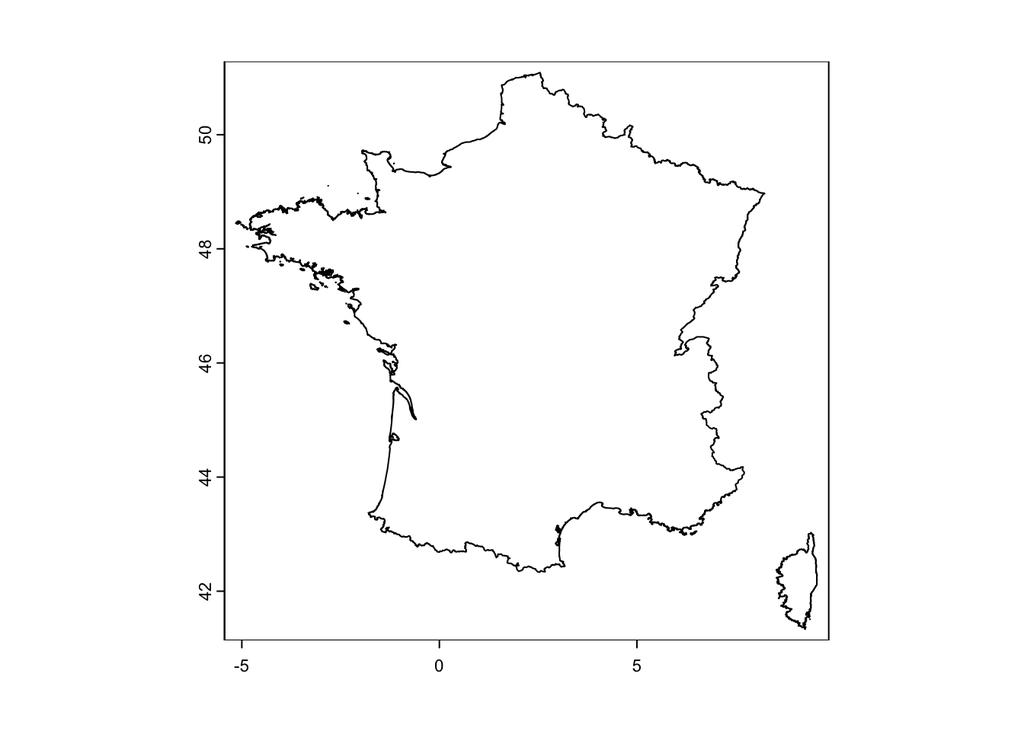

```r
### 2.1.1. Download Countries Shp to convert in SpatVector (polygon) from gadm.org/index ####
# (diva-gis.org/gdata)
## Country name to ISO
ISO <- countrycode(count, origin = 'country.name', destination = 'iso3c')
## Download country (or countries) in function if one or more countries defined
if(length(count)>1){
  #vcount_list <- list()
  for (h in ISO) {
    if(!length(list.files(path=dir_cshp,
                          pattern = h,
                          full.names = F))>0) {download.file(paste("https://geodata.ucdavis.edu/gadm/gadm4.1/shp/gadm41",
                                                                   h, "shp.zip", sep="_"),
                                                             paste(dir_cshp, paste("gadm41", h, "shp", sep="_"), sep="/"))
      unzip(paste(dir_cshp, paste("gadm41", h ,"shp", sep="_"), sep="/"), exdir=dir_cshp) }
      r <- st_read(list.files(path=dir_cshp,
                              pattern = paste("gadm41", h, "0.shp", sep="_"),
                              full.names = T))
      assign(paste("r", h, sep = "_"), r)
      rm(r)
  }
  ## Merge all
  ## Find all data frames starting with "r_" in global environment
  vcount <- vect(do.call(rbind, r_list <- mget(grep("^r_", ls(), value = TRUE))))
  rm(list = ls(pattern = "^r_"))
  # writeOGR(obj = vcount, dsn = paste(dir_cshp, paste0(count_name, ".shp"), sep="/"),
  #          driver = "ESRI Shapefile")
  #
  # st_write(vcount, paste(dir_cshp, paste0(count_name, ".shp"), sep="/"))
  #
} else {
if(length(list.files(path=dir_cshp, pattern = "_0.shp", full.names = T))==0) {
  download.file(paste("https://geodata.ucdavis.edu/gadm/gadm4.1/shp/gadm41",
                      ISO, "shp.zip", sep="_"), paste(dir_cshp,
                         paste("gadm41", ISO, "shp", sep="_"), sep="/"))
unzip(paste(dir_cshp, paste("gadm41", ISO ,"shp", sep="_"), sep="/"), exdir=dir_cshp) }
vcount <- vect(list.files(path=dir_cshp, pattern = "_0.shp", full.names = T))
plot(vcount)
}
```

## 3. Rasters environnementals (bioclimatiques et/ou édaphiques) dans le pays à étudier

La troisième étape vise à récupérer les variables environnementales, au format raster (.tif), de CHELSA et SoilGrids à l’échelle mondiale en utilisant la fonction `Chelsa.CMIP_6.download()` du package `ClimDatDownloadR` pour CHELSA, et la fonction `soil_world()` de `geodata` pour SoilGrids. Ils sont ensuite découpés en polygone (`SpatVector` du ou des pays à étudier) à l’aide de la fonction `crop()` du package `raster`. Le raster découpé est ensuite sauvegardé en utilisant la fonction `writeRaster()` du package `terra`. Les rasters CHELSA sont découpés pour chaque période et chaque scénario étudié.

**Afin de ne pas s’emmêler dans les boucles, j’ai essayé de préciser à chaque étape les différentes boucles utilisées et leur objectif.**

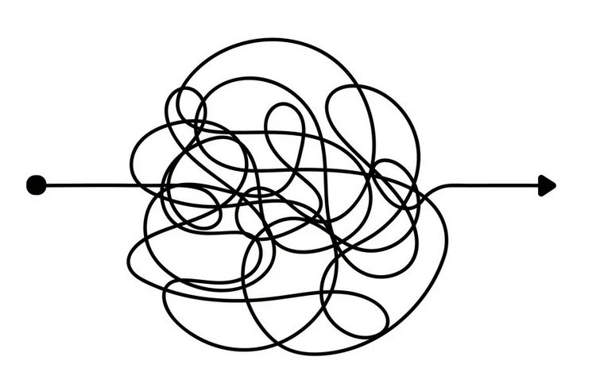

Afin de s’y retrouver…

Le code est écrit de telle sorte que si les dossiers CHELSA/SoilGrids n’existent pas déjà dans le dossier du pays ou des espèces, ils sont créés, pour CHELSA si les dossiers “periods” et “ssp” (s’il y a des scénarios) n’existent pas, ils sont créés. Si tous les dossiers existent déjà, le nombre de fichiers bioclimatiques et pédologiques (rasters) à l’intérieur est calculé, et si le nombre de fichiers est inférieur à 19, les fichiers sont créés, sinon ils ne le sont pas.

### 3.1. Variables bioclimatiques CHELSA

#### 3.1.1. Téléchargement des variables bioclimatiques CHELSA

Tout d’abord, les fichiers CHELSA sont téléchargés avec la fonction `Chelsa.CMIP_6.download()` du package `ClimDatDownloadR`.

```r
### 3.1.1. Download the CHELSA Bioclimatic variables
## ClimDatDownloadR
#install.packages("https://gitlab.rrz.uni-hamburg.de/helgejentsch/climdatdownloadr/-/archive/master/climdatdownloadr-master.tar.gz", repos = NULL, type = "source")
library(ClimDatDownloadR)
## Download with Chelsa.CMIP_6.download
# Chelsa.CMIP_6.download(save.location = paste(dir_chelsa, "ClimDatDownloadR", sep="/"),
#                        parameter = "bio",
#                        bio.var = c(1:19),
#                        emission.scenario.var = c("ssp126", "ssp370", "ssp585"),
#                        time.interval.var = c("2011-2040", "2041-2070", "2071-2100"),
#                        model.var = "gfdl-esm4",
#                        clip.extent = c(-180, 180, -90, 90))
```

#### 3.1.2. Définir l’étendue des rasters

Ensuite, les rasters bioclimatiques sont utilisés pour définir l’étendue (**extent**) qui doit être identique à celui des grilles de sol (l’étendue spatial d’un raster représente les coordonnées latitude et longitude (“X, Y”) des coins du raster dans l’espace géographique) à l’aide de la fonction `ext()` du package `terra`.

```r
## 3.1.2. Define the extent of Bioclimatic Rasters to match with Soil Rasters
j <- "1951-1980"
x <- paste0(paste(dir_chelsa, j, "Bio", sep="/"), paste(1, j, sep="_"),".tif") %>%
  rast(.)
## Crop all
c <- crop(x, vcount, mask=TRUE)
## Define extent
## The spatial extent of a raster, represents the "X, Y" coordinates of
## the corners of the raster in geographic space
ext_count <- ext(rast(c))
rm(x, c, j)
```

#### 3.1.3. Découpage des variables bioclimatiques dans le pays étudié (ici la France)

**Description des boucles:** Ce code est composé de 8 boucles `if-else`

Know if no bioclimatic variable defined?

- F -> error message
- T -> If (folder “CHELSA” already exists in Country folder?)
  - T -> for(j in period) { If (folder “period” already exists in “CHELSA” folder?)
    - T -> If (Period have Scenario?)
      - T -> for(k in ssp) { If (Scenario folder already exists in period folder?)
        - T -> If (All Rasters already created inside?)
          - T -> next }
          - F -> create it -> crop and create rasters }
        - F -> create ssp folder -> crop and create rasters }
      - F (no ssp folder) -> If (All Rasters already created inside?)
        - T -> next }
        - F -> create it -> crop and create rasters }
    - F -> create period folder -> If (Period have Scenario?)
      - T -> for(k in ssp) { create ssp folder -> crop and create rasters }
      - F (no ssp folder) -> crop and create rasters }
  - F -> create “CHELSA” folder -> for (j inperiod) { If (Period have Scenario?)
    - T -> create period folder -> for(k in ssp) {create ssp folder -> crop and create rasters}
    - F (no ssp folder) -> create period folder -> crop and create rasters }

```r
### 3.1.3. CHELSA Bioclimatic variables ####
## First know if no bioclimatic variable defined.
if (is.null(varbio)) {
    #stop("\nArgument <vars>: Please provide at least one bioclimatic variable between 1 and 19.")
    print("No bioclimatic variable defined. Please provide at least one (in varbio) or continue only with soil variable(s)")
  } else {
      if (file.exists(paste(dir_cras, "CHELSA", sep="/"))) {  # If CHELSA exists already?
        print("CHELSA folder found")
        for (j in periods) {
          #setwd(paste(dir_cras, "CHELSA", j, sep="/"))
        if (file.exists(paste(dir_cras, "CHELSA", j, sep="/"))) {       # If in CHELSA, period folder exists?
          print(paste("Folder", j, "exists", sep = " "))
          #setwd(file.path(j))
        if (length(list.files(path = paste(dir_cras, "CHELSA", j, sep="/"),
                              # If period folder exists, has it SSP?
                              pattern = "*ssp", full.names = F) ) > 0) {
          if (isFALSE(length(list.files(paste(dir_cras, "CHELSA", j, sep="/"))) == length(ssp))) {
            # If yes, has it the all SSP folders?
            for (k in ssp) {
              # No, so create SSP folder and raster files.
              if(isFALSE(file.exists(paste(dir_cras, "CHELSA", j, k, sep="/")))) {
                print(paste("In folder", j, "SSP", k, "missing", sep=" "))
            ## Loop for SSP folder
            x <- paste0(paste(dir_chelsa, j, k,"Bio", sep="/"), paste(1:19, j, k, sep="_"),".tif") %>%
              rast(.)
            ## Crop all
            compareCRS(x, vcount)
            c <- crop(x, vcount, mask=TRUE)
            rm(x)
            ## Save all
            #setwd(paste(dir_cras, "CHELSA", j, k, sep="/"))
            ## SSP
            if (!dir.exists(paste(dir_cras, "CHELSA", j, k, sep="/"))) {
              dir.create(paste(dir_cras, "CHELSA", j, k, sep="/")) }
            #setwd(file.path(k))
            ## Save rasters
            writeRaster(c, filename = paste(dir_cras, "CHELSA", j, k,
                                            paste0(paste(count_name, paste0("Bio", 1:19),
                                                         j, k, sep="_"),".tif"), sep="/"),
                        overwrite=TRUE, filetype="GTiff")
            rm(c)
            print("Files created")
              } else { print(paste("In folder", j, "SSP", k, "is presents", sep=" ")) }
            }
          }
          # If all SSP folders present, continue.
          for (k in ssp) {
            if(isFALSE(length(list.files(paste(dir_cras, "CHELSA", j, k, sep="/"))) == 19 )) {
              ## If varbio =/= ones in CHELSA folder
              print(paste("In folder", j, "SSP", k, "doesn't have all variables"))
              x <- paste0(paste(dir_chelsa, j, k,"Bio", sep="/"), 1:19, "_", j,"_", k,".tif") %>%
                        rast(.)
              ## Crop all
              compareCRS(x, vcount)
              c <- crop(x, vcount, mask=TRUE)
              rm(x)
              ## Save all
              #setwd(paste(dir_cras, "CHELSA", j, sep="/"))
              ## SSP
              if (!file.exists(paste(dir_cras, "CHELSA", j, k, sep="/"))) {
                dir.create(paste(dir_cras, "CHELSA", j, k, sep="/")) }
              #setwd(file.path(k))
              # Save rasters
              writeRaster(c, filename = paste(dir_cras, "CHELSA", j, k,
                                              paste0(paste(count_name, paste0("Bio", 1:19),
                                                           j, k, sep="_"),".tif"), sep="/"),
                          overwrite=TRUE, filetype="GTiff")
              rm(c)
              print("Files created")
              } else {print(paste("In folder", j, "SSP", k, "have all variables"))   }
          }
          # If all rasters presents in SSP folder, continue.
             } else {
               # If in period folder (with no SSP), nb rasters < nb varbio, create them.
               if(isFALSE(length(list.files(paste(dir_cras, "CHELSA", j, sep="/"))) == 19 )) {
                 print(paste("In folder", j, "doesn't have all variables", sep=" "))
                 x  <- paste0(paste(dir_chelsa, j, "Bio", sep="/"), 1:19, "_", j, ".tif") %>%
                  rast(.)
                 ## Crop all
                 compareCRS(x, vcount)
                 c <- crop(x, vcount, mask=TRUE)
                 rm(x)
                 ## Save all
                 #setwd(paste(dir_cras, "CHELSA", j, sep="/"))
                 writeRaster(c, filename = paste(dir_cras, "CHELSA", j,
                                                 paste0(paste(count_name, paste0("Bio", 1:19),
                                                              j, sep="_"),".tif"), sep="/"),
                             overwrite=TRUE, filetype="GTiff")
                 rm(c)
                 print("Files created") } else {
                   print(paste("In folder", j, " have all variables", sep= " "))  }
          }
          # Otherwise, continue.
        } else {
          # If one period folder doesn't exists,
          print(paste("Folder", j, "doesn't exist yet", sep = " "))
          #setwd(paste(dir_chelsa, j, sep="/"))
          ## If there are SSP folders (future periods)
          if (length(list.files(path = paste(dir_chelsa, j, sep="/"),
                                pattern = "*ssp", full.names = F) ) > 0) {
            #print(paste("Folder", j, "have SSP", sep = " "))
            ## Loop
            for (k in ssp) {
              print(paste0("Scenario ", k, " ..."))
              x <- paste0(paste(dir_chelsa, j, k,"Bio", sep="/"),
                          paste(1:19, j, k, sep="_"),".tif") %>%
                rast(.)
              ## Crop all
              compareCRS(x, vcount)
              c <- crop(x, vcount, mask=TRUE)
              rm(x)
              ## Save all
              #setwd(paste(dir_cras, "CHELSA", sep="/"))
              ## Folder
              if (!file.exists(paste(dir_cras, "CHELSA", j, sep="/"))) {
                dir.create(paste(dir_cras, "CHELSA", j, sep="/")) }
              #setwd(file.path(j))
              ## SSP
              if (!file.exists(paste(dir_cras, "CHELSA", j, k, sep="/"))) {
                dir.create(paste(dir_cras, "CHELSA", j, k, sep="/")) }
              #setwd(file.path(k))
              ## Save rasters
              writeRaster(c, filename = paste(dir_cras, "CHELSA", j, k,
                                              paste0(paste(count_name, paste0("Bio", 1:19),
                                                           j, k, sep="_"),".tif"), sep="/"),
                          overwrite=TRUE, filetype="GTiff")
              rm(c)
              print("Files created")
            }
            ## If there are not SSP folders (passed periods)
            } else {
            print(paste("Folder", j, "doesn't have SSP", sep = " "))
            x  <- paste0(paste(dir_chelsa, j,"Bio", sep="/"), 1:19, "_", j,".tif") %>%
              rast(.)
            ## Crop all
            compareCRS(x, vcount)
            c <- crop(x, vcount, mask=TRUE)
            rm(x)
            ## Save all
            #setwd(paste(dir_cras, "CHELSA", sep="/"))
            if (file.exists(paste(dir_cras, "CHELSA", j, sep="/"))) {
              print("The folder already exists")
            } else {
              dir.create(paste(dir_cras, "CHELSA", j, sep="/")) }
            #setwd(file.path(j))
            writeRaster(c, filename = paste(dir_cras, "CHELSA", j,
                                           paste0(paste(count_name, paste0("Bio", 1:19),
                                                        j, sep="_"),".tif"), sep="/"),
                        overwrite=TRUE, filetype="GTiff")
            rm(c)
            print("Files created")
            }
          }
      }
    } else {
          # If CHELSA doesn't exists,
        print("CHELSA was not found")
        dir.create(paste(dir_cras, "CHELSA", sep="/") )
        #setwd(file.path("CHELSA"))
      for (j in periods) {
        print(paste0("For period ", j, " ..."))
        #setwd(paste(dir_chelsa, j, sep="/"))
        ## If there are SSP folders (future periods)
        if (length(list.files(path = (paste(dir_chelsa, j, sep="/")),
                              pattern = "*ssp", full.names = F) ) > 0) {
          #print(paste("Folder", j, "have SSP", sep = " "))
          ## Loop
          for (k in ssp) {
            print(paste0("Scenario ", k, " ..."))
            x <- paste0(paste(dir_chelsa, j, k,"Bio", sep="/"), 1:19, "_", j,"_", k,".tif") %>%
              rast(.)
            ## Crop all
            compareCRS(x, vcount)
            c <- crop(x, vcount, mask=TRUE)
            rm(x)
            ## Save all
            #setwd(paste(dir_cras, "CHELSA", sep="/"))
            ## Folder
            if (!file.exists(paste(dir_cras, "CHELSA", j, sep="/"))) {
              dir.create(paste(dir_cras, "CHELSA", j, sep="/")) }
            #setwd(file.path(j))
            ## SSP
            if (!file.exists(paste(dir_cras, "CHELSA", j, k, sep="/"))) {
              dir.create(paste(dir_cras, "CHELSA", j, k, sep="/")) }
            #setwd(file.path(k))
            ## Save rasters
            writeRaster(c, filename = paste(dir_cras, "CHELSA", j, k,
                                            paste0(paste(count_name, paste0("Bio", 1:19),
                                                         j, k, sep="_"),".tif"), sep="/"),
                        overwrite=TRUE, filetype="GTiff")
            rm(c)
            print("Files created")
          }
          # If there are not SSP folders (passed periods)
        } else {
          x  <- paste0(paste(dir_chelsa, j, "Bio", sep="/"), 1:19, "_", j,".tif") %>%
            rast(.)
          ## Crop all
          compareCRS(x, vcount)
          c <- crop(x, vcount, mask=TRUE)
          rm(x)
          ## Save all
          #setwd(paste(dir_cras, "CHELSA", sep="/"))
          if (file.exists(paste(dir_cras, "CHELSA", j, sep="/"))) {
            print("The folder already exists")
          } else {
            dir.create(paste(dir_cras, "CHELSA", j, sep="/")) }
          #setwd(file.path(j))
          writeRaster(c, filename = paste(dir_cras, "CHELSA", j,
                                         paste0(paste(count_name, paste0("Bio", 1:19),
                                                      j, sep="_"),".tif"), sep="/"),
                      overwrite=TRUE, filetype="GTiff")
          rm(c)
          print("Files created")
        }
      }
    }
   print("Done")}
```

```
## [1] "CHELSA folder found"
## [1] "Folder 1951-1980 exists"
## [1] "In folder 1951-1980  have all variables"
## [1] "Folder 1981-2010 exists"
## [1] "In folder 1981-2010  have all variables"
## [1] "Folder 2011-2040 exists"
## [1] "In folder 2011-2040 SSP ssp126 have all variables"
## [1] "In folder 2011-2040 SSP ssp370 have all variables"
## [1] "In folder 2011-2040 SSP ssp585 have all variables"
## [1] "Folder 2041-2070 exists"
## [1] "In folder 2041-2070 SSP ssp126 have all variables"
## [1] "In folder 2041-2070 SSP ssp370 have all variables"
## [1] "In folder 2041-2070 SSP ssp585 have all variables"
## [1] "Folder 2071-2100 exists"
## [1] "In folder 2071-2100 SSP ssp126 have all variables"
## [1] "In folder 2071-2100 SSP ssp370 have all variables"
## [1] "In folder 2071-2100 SSP ssp585 have all variables"
## [1] "Done"
```

### 3.2. Les variables édaphiques

**Description des boucles:** Ce code est composé de 3 boucles `if-else`

If (know if no soilgrid variable defined?)

- F -> error message
- T -> If (folder “SoilGrids” already exists in Country folder?)
  - T -> If (All Rasters already created inside?)
    - T -> next
    - F -> crop and create rasters
  - F -> create “SoilGrids” folder -> crop and create rasters

```r
### 3.2. Soil Grid variables ####
if (is.null(soil)) { print("No soil variable defined. Please provide at least one (in soil) or continue only with bioclimatic variable(s)")
} else {
  ## Download SOIL GRIDS variables
  print("Soil variables defined.")
  soil_avail <- character()
  for (s in soil){
    for (d in dep){
      if (!file.exists(paste0(dir_soil, "/", s,"_", d,"cm_mean_30s.tif"))) { #If file not yet exists, download it
        print("Download in progress...")
        depth2 <- str_extract(d,'\\b\\w+$')
        for(e in depth2) {
          print(paste("File", s,d, "not yet available", sep=" "))
          varsoil <- soil_world(var=s , depth=as.numeric(e), stat="mean", path=dir_soil)
        }
        rm(e)
      } else {
        print(paste("File", s,d, "already downloaded", sep=" "))
        soil_avail <- c(soil_avail, paste(s, d, sep="_"))
      }
    }
  }
  soil <- unique(str_extract(soil_avail, "[^_]+"))
  dep <- unique(str_extract(soil_avail, "[^_]+$"))
  depth <- paste0(dep, "cm")

  ### Loop GIS in count to study
  if (file.exists(paste(dir_cras, "SoilGrids", sep="/"))) {
    # If SoilGrids folder already exist
    if (isFALSE(all((do.call(paste, c(expand.grid(soil, depth), sep="_"))) %in%
                    (str_extract(list.files(paste(dir_cras, "SoilGrids", sep="/")),
                                 "(?<=_)[^_]+_[^_]+(?=\\.tif$)")) )) ) {
      print("Soil variables missing in SoilGrids folder")
      #} else { print("No missing")}

      x <- paste(dir_soil, (list.files(dir_soil,
                                       pattern=paste0((do.call(paste, c(expand.grid(soil, depth), sep="_"))),
                                                      collapse="|"))), sep="/") %>%
        rast(.)
      ## Crop all
      compareCRS(x, vcount)
      c <- crop(x, vcount, mask=TRUE)
      rm(x)
      ## Change extent of Soil Raster
      ext(c) <- ext_count
      ## Save rasters
      for (z in c@ptr$names) {
        writeRaster(c[z], filename = paste(dir_cras,"SoilGrids",
                                           paste0(paste(count_name, z, sep="_"),
                                                  ".tif"), sep="/"),
                    overwrite=TRUE, filetype="GTiff") }
      rm(c, z)
      print("Files created")
    }
  } else {
    print("The SoilGrids folder was not found, it must be created")
    dir.create(paste(dir_cras, "SoilGrids", sep="/"))
    #setwd(file.path("SoilGrids"))
    x <- paste(dir_soil, (list.files(dir_soil,
                                     pattern=paste0((do.call(paste, c(expand.grid(soil, depth), sep="_"))),
                                                    collapse="|"))), sep="/") %>%
      rast(.)
    ## Crop all
    compareCRS(x, vcount)
    c <- crop(x, vcount, mask=TRUE)
    rm(x)
    ## Change extent of Soil Raster
    ext(c) <- ext_count
    ## Save rasters
    for (z in c@ptr$names) {
      writeRaster(c[z], filename = paste(dir_cras,"SoilGrids",
                                         paste0(paste(count_name, z, sep="_"),
                                                ".tif"), sep="/"),
                  overwrite=TRUE, filetype="GTiff") }
    rm(c, z)
    print("Files created") }
  print("Done")}
```

```
## [1] "No soil variable defined. Please provide at least one (in soil) or continue only with bioclimatic variable(s)"
```

## 4. Aire d’indigénat des espèces étudiées

Étape 4, téléchargement de l’aire d’indigène (`Shapefile` converti en `SpatVector`) de l’espèce définie à étudier (uniquement sur la période de référence “1951-1980” car l’aire d’indigénat est calibrée sur la distribution de l’espèce avant 1980), sauvegardée en tant que `range`.

```r
period <- "1951-1980"
```

La boucle est définie telle que :

### 4.1. Téléchargement du Shapefile et le convertir en SpatVector

If ( Species folder with Native Range (NR) Shapefile exists or not? )

- T -> If ( Shapefile ‘plg.shp’ found ? )
  - T -> download it
  - F -> If ( Shapefile ‘.shp’ exists ? )
    - T -> download it
    - F -> error message (shapefile no found)
- F -> error message (folder no found)

```r
### 4.1. Download Vector of Native Range ####
    ## First, looking for if NR shp for given species exists
    ## Create "range" one time, use after to crop CHELSA and SoilGRIDS var
    if (file.exists(paste(dir_set, i, sep="/"))) {
      ## Species folder
      d <- (paste(dir_set, i, sep="/"))
      file <- list.files(path = d, pattern = "_plg_clip.shp$", full.names = F)

      if (length(file) > 0) {
        print("clip Shapefile find")
      } else {
        print("Try to find shapefile ... ")

        d <- (paste(dir_set, i, sep="/"))
        file <- list.files(path = d, pattern = "_plg.shp$", full.names = F)

        if (length(file) > 0) {
          print("plg Shapefile find")
        } else {
          print("Try to find shapefile ... ")

          d <- (paste(dir_set, i, sep="/"))
          file <- list.files(path = d, pattern = "\\.shp$", full.names = F)
          if (length(file) < 0) {
            print("Error, no found")
          } else {
            print("Ok good, shp Shapefile was found") } } }

      range <- vect(paste(dir_set, i, file, sep="/"))
      crs(range) <- "epsg:4326"
      par(mfrow=c(1, 1))
      #plot(range)
      } else {
        print(paste0("The Native Range Folder for ", i, " doesn't exists!")) }
```

```
## [1] "Try to find shapefile ... "
## [1] "Try to find shapefile ... "
## [1] "Ok good, shp Shapefile was found"
```

```r
    ## Define the extent of Bioclimatic Rasters to match with Soil Rasters
    x <- paste0(paste(dir_chelsa, period,"Bio", sep="/"), paste(1, period, sep="_"),".tif") %>% rast(.)
    ## Crop all
    # compareCRS(x, range)
    c <- crop(x, range, mask=TRUE)
    ext_nr <- ext(rast(c))
    rm(x, c)
```

SpatVector de l’aire d’indigénat de l’espèce :

```r
range
```

```
##  class       : SpatVector
##  geometry    : polygons
##  dimensions  : 12, 5  (geometries, attributes)
##  extent      : -95.69039, -76.87229, 32.40928, 41.12437  (xmin, xmax, ymin, ymax)
##  source      : robipseu.shp
##  coord. ref. : lon/lat WGS 84 (EPSG:4326)
##  names       :    AREA PERIMETER ROBIPSEU_ ROBIPSEU_I  CODE
##  type        :   <num>     <num>     <int>      <int> <int>
##  values      :   32.82     34.41         2          1     1
##                0.06328    0.9578         3          2     1
##                  8.228     17.87         4          3     1
```

### 4.2. Découpage des rasters dans l’aire d’indigénat des espèces étudiées

Comme pour le pays étudié, les rasters environnementaux (CHELSA et Soil) sont découpés en polygone, un `SpatVector` dans l’aire d’indigénat de l’espèce étudiée, en utilisant la fonction `crop()` du package `raster`. Le raster découpé est ensuite sauvegardé à l’aide de la fonction `writeRaster()` du package `terra`. Les variables CHELSA sont découpées pour chaque période et chaque scénario étudié, tandis que les variables Soil ne sont découpées que pour une seule période.

#### 4.2.1. Si le dossier d’espèces n’a pas encore été créé

La boucle définit si le dossier des espèces étudiées a déjà été créé ou non.

- F -> create Species folder ->
  - If ( Bioclimatic variables no null ?)
    - T -> crop and create rasters
    - F -> next
  - If ( Soil variables no null ?)
    - T -> crop and create rasters
    - F -> next

Note : Les données Soil et Bioclim. ne peuvent pas être tous les deux nuls, mais l’un d’entre eux peut l’être si l’on souhaite étudiée les variables bioclimatiques ou édaphiques indépendamment de l’autre.

#### 4.2.2. Si le dossier d’espèces est déjà créé

Cette boucle est réalisée si le fichier est déjà créé, il s’agit maintenant de savoir s’il est complet.

- T -> Species folder directory
  - If ( Bioclimatic variables no null ?)
    - T -> If ( “CHELSA” folder already exists in Species folder ? )
      - T -> If ( period “1951-1980” folder already exits ? )
        - T -> If (All the rasters of all bioclim. variables defined are already created ?)
          - T -> next
          - F -> (re)crop and (re)create rasters
        - F -> create it -> crop and create rasters
      - F -> create “CHELSA” -> create “1951-1980” folder -> crop and create rasters
    - F -> next
  - If ( Soil variables no null ?)
    - T -> If ( “SOILGRID” folder already exists in Species folder ? )
      - T -> If ( All the rasters of all Soil variables defined are already created ? )
        - T -> next
        - F -> (re)crop and (re)create rasters
      - F -> create it -> crop and create rasters
    - F -> next

```r
### 4.2. Species Folder creation ####
## 4.2.1. Species Folder not already created ####
if (!file.exists(paste(dir_nrr, i, sep="/"))) {
  print(paste("Native Range of", i,"doesn't exist yet", sep=" "))
  dir.create(paste(dir_nrr, i, sep="/"))
  ## CHELSA Bioclimatic variables
  if (!is.null(varbio)) {
    #setwd(paste(dir_nrr, i, "CHELSA", sep="/"))
      dir.create(paste(dir_nrr, i, "CHELSA", sep="/"))
      #setwd(file.path("CHELSA"))
      dir.create(paste(dir_nrr, i, "CHELSA", period, sep="/"))
      #setwd(file.path(period))
      for (v in 1:19) {
      x <- paste0(paste(dir_chelsa, period,"Bio", sep="/"), v, "_",
                  period,".tif") %>% rast(.)
      ## Crop all
      compareCRS(x, range)
      c <- crop(x, range, mask=TRUE)
      #plot(c[[1]])
      rm(x)
      ## Save rasters
      writeRaster(c, filename = paste(dir_nrr, i, "CHELSA", period,
                                      paste0(paste(i, paste0("Bio", v),
                                          period, sep="_"),".tif"), sep="/"),
                  overwrite=TRUE, filetype="GTiff")
      rm(c) }
      print("Files created")
    }
  ## SOILGRIDS variables
  if (!is.null(soil)) {
    #setwd(paste(dir_nrr, i, sep="/"))
      dir.create(paste(dir_nrr, i, "SoilGrids", sep="/"))
      #setwd(file.path("SoilGrids"))
      y <- paste(dir_soil, (list.files(dir_soil,
                                       pattern=paste0((do.call(paste, c(expand.grid(soil, depth), sep="_"))),
                                                      collapse="|"))), sep="/")  %>%
        rast(.)
      ## Crop all
      compareCRS(y, range)
      c <- crop(y, range, mask=TRUE)
      rm(y)
      ## Change extent of Soil Raster
      ext(c) <- ext_nr
      ## Save rasters
      for (z in c@ptr$names) {
        writeRaster(c[z], filename = paste(dir_nrr, i, "SoilGrids",
                                           paste0(paste(i, z, sep="_"),
                                                  ".tif"), sep="/"),
                    overwrite=TRUE, filetype="GTiff") }
      rm(c, z)
      print("Files created")
    }
} else {
  ### 4.2.2. If Species Folder already created ####
  print(paste("Native Range of", i,"already created", sep=" "))
  #setwd(paste(dir_nrr, i, sep="/"))
  ### 4.2.2.1. CHELSA Bioclimatic variables ####
  if (!is.null(varbio)) {
    if (file.exists(paste(dir_nrr, i, "CHELSA", sep="/"))) {
      #setwd(file.path("CHELSA"))
      if(file.exists(paste(dir_nrr, i, "CHELSA", period, sep="/"))) {
        if(isFALSE(length(list.files(paste(dir_nrr, i, "CHELSA", period, sep="/"))) == 19 )) {
          ## If varbio =/= ones in CHELSA folder
          print(paste("CHELSA for", i, "doesn't have all variables", sep=" "))
          ## CHELSA world rasters
          for (v in 1:19) {
          x <- paste0(paste(dir_chelsa, period,"Bio", sep="/"), v, "_", period,".tif") %>%
            rast(.)
          ## Crop all
          compareCRS(x, range)
          c <- crop(x, range, mask=TRUE)
          rm(x)
          ## Save rasters
          #setwd(paste(dir_nrr, i, "CHELSA", period, sep="/"))
          writeRaster(c, filename = paste(dir_nrr, i, "CHELSA", period,
                                          paste0(paste(i, paste0("Bio", v),
                                             period, sep="_"),".tif"), sep="/"),
                      overwrite=TRUE, filetype="GTiff")
          rm(c) }
          print("Files created")
        } else {print(paste("CHELSA for", i, "have all variables", sep=" "))}
      } else {
        print(paste("Folder", period, "doesn't exist yet", sep=" "))
        #setwd(paste(dir_nrr, i, "CHELSA", sep="/"))
        dir.create(paste(dir_nrr, i, "CHELSA", period, sep="/"))
        #setwd(file.path(period))
        ## CHELSA world rasters
        for (v in 1:19) {
        x <- paste0(paste(dir_chelsa, period,"Bio", sep="/"), v, "_", period,".tif") %>%
          rast(.)
        ## Crop all
        compareCRS(x, range)
        c <- crop(x, range, mask=TRUE)
        rm(x)
        ## Save rasters
        writeRaster(c, filename = paste(dir_nrr, i, "CHELSA", period,
                                        paste0(paste(i, paste0("Bio", v),
                                          period, sep="_"),".tif"), sep="/"),
                    overwrite=TRUE, filetype="GTiff")
        rm(c) }
        print("Files created") }
    } else {
      dir.create(paste(dir_nrr, i, "CHELSA", sep="/"))
      #setwd(file.path("CHELSA"))
      dir.create(paste(dir_nrr, i, "CHELSA", period, sep="/"))
      #setwd(file.path(period))
      ## CHELSA world rasters
      for (v in 1:19) {
      x <- paste0(paste(dir_chelsa, period,"Bio", sep="/"), v, "_", period,".tif") %>%
        rast(.)
      ## Crop all
      compareCRS(x, range)
      c <- crop(x, range, mask=TRUE)
      rm(x)
      ## Save rasters
      writeRaster(c, filename = paste(dir_nrr, i, "CHELSA", period,
                                      paste0(paste(i, paste0("Bio", v),
                                       period, sep="_"),".tif"), sep="/"),
                  overwrite=TRUE, filetype="GTiff")
      rm(c) }
      print("Files created")
    }
  }
  ### 4.2.1.2. SOIL GRIDS variables ####
  if (!is.null(soil)) {
    if (file.exists(paste(dir_nrr, i, "SoilGrids", sep="/"))) {
      #setwd(file.path("SoilGrids"))
      ## If there are or not soil variables
      if (isFALSE(all((do.call(paste, c(expand.grid(soil, depth), sep="_"))) %in%
                      (str_extract(list.files(paste(dir_nrr, i, "SoilGrids", sep="/")),
                                   "(?<=_)(.+)(?=\\.)")) )) ) {
        print(paste("SoilGrids for", i, "doesn't have all the variables", sep=" "))
        ## SoilGRIDS world rasters
        y <- paste(dir_soil, (list.files(dir_soil,
                                         pattern=paste0((do.call(paste, c(expand.grid(soil, depth), sep="_"))),
                                                        collapse="|"))), sep="/") %>% rast(.)
        ## Crop all
        compareCRS(y, range)
        c <- crop(y, range, mask=TRUE)
        rm(y)
        ## Change extent of Soil Raster
        ext(c) <- ext_nr
        ## Save rasters
        for (z in c@ptr$names) {
          writeRaster(c[z], filename = paste(dir_nrr, i, "SoilGrids",
                                             paste0(paste(i, z, sep="_"),
                                                    ".tif"), sep="/"),
                      overwrite=TRUE, filetype="GTiff") }
        rm(c, z)
        print("Files created") }
    } else {
      dir.create(paste(dir_nrr, i, "SoilGrids", sep="/"))
      #setwd(file.path("SoilGrids"))
      ## SoilGRIDS world rasters
      y <- paste(dir_soil, (list.files(dir_soil,
                                       pattern=paste0((do.call(paste, c(expand.grid(soil, depth), sep="_"))),
                                                      collapse="|"))), sep="/") %>% rast(.)
      ## Crop all
      compareCRS(y, range)
      c <- crop(y, range, mask=TRUE)
      rm(y)
      ## Change extent of Soil Raster
      ext(c) <- ext_nr
      ## Save rasters
      for (z in c@ptr$names) {
        writeRaster(c[z], filename = paste(dir_nrr, i, "SoilGrids",
                                           paste0(paste(i, z, sep="_"),
                                                  ".tif"), sep="/"),
                    overwrite=TRUE, filetype="GTiff") }
      rm(c, z)
      print("Files created")
    }
  }
}
```

```
## [1] "Native Range of Robinia pseudoacacia already created"
## [1] "CHELSA for Robinia pseudoacacia have all variables"
```

```r
print ("Done")
```

```
## [1] "Done"
```

## 5. Sauvegarde des rasters dans des Data frames

Étape 5: L’objectif est de combiner les points des rasters (les variables environnementales dans l’espace environnemental) de l’aire d’indigénat de l’espèce étudiée avec celle du pays d’introduction. Convertir les rasters dans des data frames pour les fusionner ensuite.

### 5.1. Les rasters de l’aire d’indigénats

Créer le data frame pour l’espèce, nommé `rdf_spe`, à partir des rasters, selon que les variables environnementales définies.

La fonction `aggregate` permet de passer d’une résolution de 1km^2 (~0.01°) à 10km^2 (0.1°) afin de réduire le temps de travail sous R. A terme, l’objectif est de réitérer l’approche avec chaque point de 1km^2.

```r
### 5.1. Load Rasters in NR species (CHELSA + SoilGRIDS) ####
if (is.null(varbio)) {
  ## When there are only Soil variables
   rast_spe <- paste0(paste(dir_nrr, i,"SoilGrids/", sep="/"),
                      paste(i, (do.call(paste, c(expand.grid(soil, depth),
                                                 sep="_"))), sep="_"), ".tif") %>%
     rast(.)

   ## Aggregate (returns the result in a convenient form)
   rast_spe <- aggregate(rast_spe, fact = 0.1/res(rast_spe), FUN=sum, na.rm=T, na.action=NULL)
   ### Create data.frame
   rdf_spe <- as.data.frame(rast_spe, na.rm=NA, xy=TRUE, cell=T)
   #rdf_spe <- rownames_to_column(rdf_spe, var = "cell")
   #rm(rast_spe)
   } else {
     if (is.null(soil)) {
       ## When there are only Bioclimatic variables
       rast_spe <- paste0(paste(dir_nrr, i,"CHELSA", "1951-1980",
                            i, sep="/"), "_Bio", varbio, "_1951-1980.tif") %>%
         rast(.)

       ## Aggregate (returns the result in a convenient form)
       rast_spe <- aggregate(rast_spe, fact = 0.1/res(rast_spe), FUN=sum, na.rm=TRUE, na.action=NULL)
       ### Create data.frame
       rdf_spe <- as.data.frame(rast_spe, na.rm=TRUE, xy=TRUE, cell=T)
       #rdf_spe <- rownames_to_column(rdf_spe, var = "cell")
       #rm(rast_spe)
     } else {
       ## When there are both
       rast_soil <- paste0(paste(dir_nrr, i,"SoilGrids/", sep="/"),
                          paste(i, (do.call(paste, c(expand.grid(soil, depth),
                                                     sep="_"))), sep="_"), ".tif") %>%
         rast(.)
       rast_chel <- paste0(paste(dir_nrr, i,"CHELSA", "1951-1980",
                                i, sep="/"), "_Bio", varbio, "_1951-1980.tif") %>%
         rast(.)
       rast_chel <- resample(rast_chel, rast_soil, method = "bilinear")
       rast_spe <- c(rast_chel, rast_soil)
       rm(rast_soil, rast_chel)

       ## Aggregate (returns the result in a convenient form)
       rast_spe <- aggregate(rast_spe, fact = 0.1/res(rast_spe), FUN=sum, na.rm=TRUE, na.action=NULL)
       ### Create data.frame
       rdf_spe <- as.data.frame(rast_spe, na.rm=TRUE, xy=TRUE, cell=T)
       #rdf_spe <- rownames_to_column(rdf_spe, var = "cell")
       #rm(rast_spe)
     } }

## Rename columns in function if varbio, soil or neither NULL
if (is.null(varbio)) {
  colnames(rdf_spe) <- c("cell", "x", "y",
                        paste0((do.call(paste, c(expand.grid(soil, depth), sep="_")))))
} else {
  if (is.null(soil)) { colnames(rdf_spe) <- c("cell", "x", "y", paste0("Bio",varbio)) } else {
    colnames(rdf_spe) <- c("cell", "x", "y", paste0("Bio",varbio),
                          paste0((do.call(paste, c(expand.grid(soil, depth), sep="_"))))) } }
rdf_spe["Source"]="Aire indigénat"

## Add "nr" (native range) to cell values in data
rdf_spe$cell <- sub("^","nr_",rdf_spe$cell)
## Remove column if only NA inside
rdf_spe <- rdf_spe[,colSums(is.na(rdf_spe))<nrow(rdf_spe)]
```

Tracer les rasters des variables bioclimatiques “Bio1” dans l’aire d’indigénat de l’espèce comme exemples.

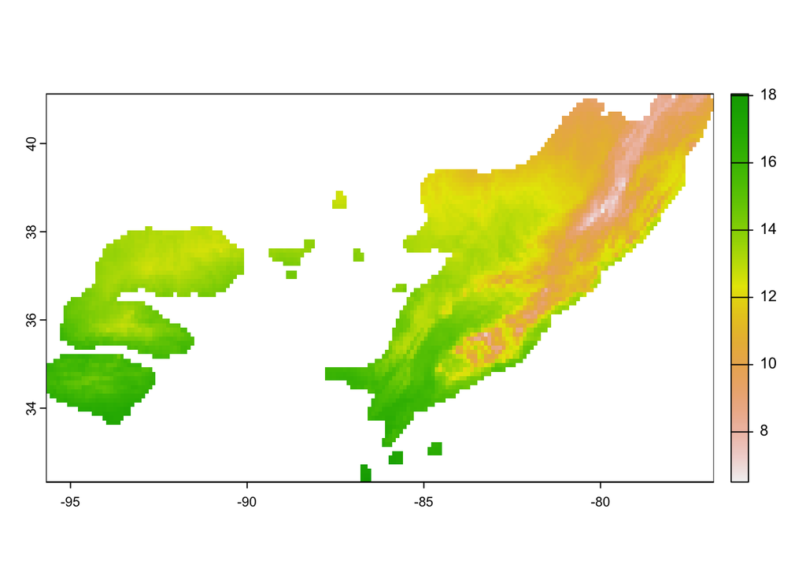

```r
plot(rast_spe$`Bio1_1951-1980`)
```

### 5.2. Les rasters dans le pays d’introduction

Comme pour le point 5.1, un data frame pour le pays d’introduction, nommé `rdf_count`, est créé à partir des rasters, selon que les variables environnementales définis. Mais pour chaque période et chaque scénario (s’il y en a un).

```r
### 5.2. Rasters in Country (CHELSA + SoilGRIDS) ####
print("Convert rasters to Data Frames")
```

```
## [1] "Convert rasters to Data Frames"
```

```r
## Loop for each periods
rdf_count <- data.frame()
if (is.null(varbio)) {
  ## When there are only soil variables
  print("Only for soil variables")
  rast_c <- paste(dir_cras, "SoilGrids", paste0(paste(count_name, (do.call(paste, c(expand.grid(soil, depth), sep="_"))), sep="_"),
                                                ".tif"), sep="/") %>%
    rast(.)
  ## Aggregate (returns the result in a convenient form)
  rast_c<-aggregate(rast_c, fact = 0.1/res(rast_c), FUN=sum, na.rm=T, na.action=NULL)
  ## Create data.frame
  rdf <- as.data.frame(rast_c, na.rm=NA, xy=TRUE, cell=T)
  #rm(rast_c)

  ## Rename columns in function if varbio, soil or neither NULL
  colnames(rdf) <- c("cell", "x", "y",
                     paste0((do.call(paste, c(expand.grid(soil, depth), sep="_")))))
  rdf["Source"]= count_name
  ## Add country abbreviation to cell (rownames) in data
  rdf$cell <- sub("^",paste0( (substr(count_name, start = 1, stop = 2)), sep="_"),rdf$cell)
  ## Add 'rdf' in 'rdf_count'
  rdf_count <- rbind(rdf, rdf_count)
  ## Remove column if only NA inside
  rdf_count <- rdf_count[,colSums(is.na(rdf_count))<nrow(rdf_count)]
} else {
  for (j in periods) {
    ## If there are SSP folders (future periods) ?
    if (length(list.files(path = paste(dir_cras,"CHELSA",j, sep="/"),
                          pattern = "*ssp", full.names = F) ) > 0) {
      ### 5.2.1. Periods with Scenarios ####
      print(paste0("Period ", j, " ..."))
      for (k in ssp) {
        print(paste0("Scenario ", k, " ..."))

        ### Rasters in Country to study (CHELSA + SoilGRIDS)
          if (is.null(soil)) {
            ## Where there are only bioclimatic variables
            rast_c <- paste0(paste(paste(dir_cras, "CHELSA", j, k, count_name, sep="/"), paste0("Bio",
                                                                                           varbio), j, k, sep="_"), ".tif") %>%
              rast(.)
          } else {
            ## When there are both
            rast_c <- c(paste0(paste(paste(dir_cras, "CHELSA", j, k, count_name, sep="/"),
                                     paste0("Bio", varbio), j, k, sep="_"), ".tif"),
                        paste(dir_cras, "SoilGrids",
                              paste0(paste(count_name, (do.call(paste, c(expand.grid(soil, depth), sep="_"))),
                                           sep="_"), ".tif"), sep="/")) %>%
              rast(.)
          }
      ## Aggregate (returns the result in a convenient form)
      rast_c<-aggregate(rast_c, fact = 0.1/res(rast_c), FUN=sum, na.rm=T, na.action=NULL)
      ## Create data.frame
      rdf <- as.data.frame(rast_c, na.rm=T, xy=TRUE, cell=T)
      #rm(rast_c)

      ## Rename columns in function if varbio, soil or neither NULL
        if (is.null(soil)) { colnames(rdf) <- c("cell", "x", "y", paste0("Bio",varbio)) } else {
          colnames(rdf) <- c("cell", "x", "y", paste0("Bio",varbio),
                             paste0((do.call(paste, c(expand.grid(soil, depth), sep="_"))))) }
      rdf["Source"]= paste0(count_name, "_", j, k)
      ## Add country abbreviation to cell (rownames) in data
      rdf$cell <- sub("^",paste0( (substr(count_name, start = 1, stop = 2)), j, k, sep="_"),rdf$cell)
      ## Add 'rdf' in 'rdf_count'
      rdf_count <- rbind(rdf, rdf_count)
    }
      } else {
      ### 5.2.2. Periods without Scenarios ####
      print(paste0("Period ", j, " ..."))
        if (is.null(soil)) {
          ## When there are only bioclimatic variables
          rast_c <- paste0(paste(paste(dir_cras, "CHELSA", j, count_name, sep="/"),
                                 paste0("Bio", varbio), j, sep="_"), ".tif") %>%
            rast(.)
        } else {
          ## When there are both
          rast_c <- c(paste0(paste(paste(dir_cras, "CHELSA", j, count_name, sep="/"),
                                   paste0("Bio", varbio), j, sep="_"), ".tif"),
                      paste(dir_cras, "SoilGrids",
                            paste0(paste(count_name, (do.call(paste, c(expand.grid(soil, depth), sep="_"))),
                                         sep="_"), ".tif"), sep="/")) %>%
            rast(.)
        }
  ## Aggregate (returns the result in a convenient form)
  rast_c<-aggregate(rast_c, fact = 0.1/res(rast_c), FUN=sum, na.rm=TRUE, na.action=NULL)
  ## Create data.frame
  rdf <- as.data.frame(rast_c, na.rm=TRUE, xy=TRUE, cell=T)
  #rm(rast_c)

  ## Rename columns in function if varbio, soil or neither NULL
    if (is.null(soil)) { colnames(rdf) <- c("cell", "x", "y", paste0("Bio",varbio)) } else {
      colnames(rdf) <- c("cell", "x", "y", paste0("Bio",varbio),
                         paste0((do.call(paste, c(expand.grid(soil, depth), sep="_"))))) }
  rdf["Source"]= paste(count_name ,j, sep="_")
  ## Add country abbreviation to cell (rownames) in data
  rdf$cell <- sub("^",paste0( (substr(count_name, start = 1, stop = 2)), j, sep="_"),rdf$cell)
  ## Add 'rdf' in 'rdf_count'
  rdf_count <- rbind(rdf, rdf_count)
      }
    }
  }
```

```
## [1] "Period 1951-1980 ..."
## [1] "Period 1981-2010 ..."
## [1] "Period 2011-2040 ..."
## [1] "Scenario ssp126 ..."
## [1] "Scenario ssp370 ..."
## [1] "Scenario ssp585 ..."
## [1] "Period 2041-2070 ..."
## [1] "Scenario ssp126 ..."
## [1] "Scenario ssp370 ..."
## [1] "Scenario ssp585 ..."
## [1] "Period 2071-2100 ..."
## [1] "Scenario ssp126 ..."
## [1] "Scenario ssp370 ..."
## [1] "Scenario ssp585 ..."
```

Tracer les rasters des variables bioclimatiques “Bio1” en France métropolitaine comme exemples.

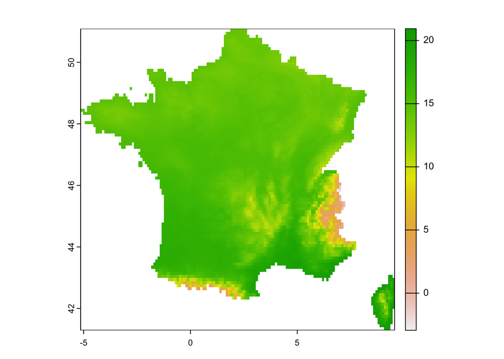

```r
plot(rast_c[[1]])
```

## 6. ACP (Espace environnemental) et Sélection des points

Étape 6: Création d’une ACP, qui permet d’obtenir l’espace environnemental représentant les conditions environnementales (issues des variables environnementales étudiées) au sein du pays d’introduction et de l’aire d’indigénat de l’espèce étudiée (Figure 1a).

Une fois l’espace environnemental dessiné, les points du pays d’introduction qui se trouvent proches de ceux représentés de l’aire d’indigénat de l’espèce sont sélectionnés (ellipse noir, Figure 1b) et sauvegardé dans `dist_list`. Cela signifie que les conditions environnementales de ces points (pays) sont proches de celles dans l’aire d’indigène de l’espèce, la distance maximum entre les points étant définie par une distance maximale (md). A la fin, un data frame `map_list` avec seulement ces points sélectionnés permettra de projeter ces points sur les cartes du pays.

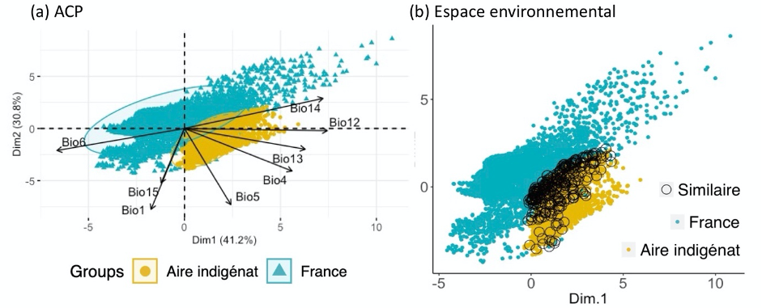

### 6.1. ACP (Espace environnemental)

```r
### 6.1. PCA (Environmental space) ####
print("Projecte in Environmental space (PCA)")
```

```
## [1] "Projecte in Environmental space (PCA)"
```

```r
## Plots with PCA
pca_list <- list()
## Data frame with coordinates (get_pca_ind)
ind_list <- list()
### 6.1.1. For Soil variables ####
if (is.null(varbio)) {
## Merge / make the combine species and country data
merg <-rbind(
  rdf_count[rdf_count$Source == count_name, ],
  rdf_spe)
merg <- na.omit(merg)
## tag individus
rownames(merg) <- merg$cell

## Select quantitative variables in function if varbio, soil or neither NULL
## dudi.pca (ade4) to run the PCA on a centered and reduced data table.

merg %>%
  dplyr::select(-c("cell", "x", "y", "Source")) %>%
  dudi.pca(scannf = FALSE, nf = 2) -> res_acp

## Scree plot of the PCA eigenvalues,
plot_vp <- fviz_eig(res_acp, addlabels = TRUE)
plot_vp
#get_eigenvalue(res_acp)

## Visualisation of ind
chemElement <- "ind_soil"
ind <- get_pca_ind(res_acp)
ind_list[[chemElement]]  <- ind

### Individuals PCA
chemElement <- "pca_soil"
plot_ind <- fviz_pca_biplot(res_acp,
                            geom.ind = "point",
                            # Montre les points seulement
                            # (mais pas le "text")
                            col.ind = merg$Source, # colorer by groups
                            col.var = "black",
                            palette = c(
                              "#E7B800",
                              "#00AFBB"),
                            # select.ind = list(name = ),
                            addEllipses = TRUE,
                            # Ellipses de concentration
                            legend.title = "Groups",
                            repel = TRUE) +
  theme(legend.position = "bottom") +
  ggtitle("(a)") +
  theme(plot.title = element_text(size = 25, face = "bold"),
        axis.text=element_text(size=17),
        axis.title=element_text(size=17),
        legend.text = element_text(size=20))
plot_ind
pca_list[[chemElement]]  <- plot_ind
} else {
### 6.1.2. For Bioclimatic variables ####
for (j in periods) {
  ## If there are SSP folders (future periods) ?
  if (length(list.files(path = paste(dir_cras,"CHELSA",j, sep="/"),
                        pattern = "*ssp", full.names = F) ) > 0) {
    ## 6.1.1. Periods with Scenarios ####
    print(paste0("Period ", j, " ..."))
    for (k in ssp) {
      print(paste0("Scenario ", k, " ..."))
      ## Merge / make the combine species and country data
      merg <-rbind(
        rdf_count[rdf_count$Source == (paste0(count_name, "_", j, k)), ],
        rdf_spe)
      ## tag individus
      rownames(merg) <- merg$cell
      ## Add column with country name and natif
      c <- sub("_.*", "", merg$Source)
      merg['Country'] <- c
      rm(c)

      ## Select quantitative variables in function if varbio, soil or neither NULL
      ## dudi.pca (ade4) to run the PCA on a centered and reduced data table.

      merg %>%
        dplyr::select(-c("cell", "x", "y", "Source", "Country")) %>%
        dudi.pca(scannf = FALSE, nf = 2) -> res_acp

      ## Scree plot of the PCA eigenvalues,
      plot_vp <- fviz_eig(res_acp, addlabels = TRUE)
      plot_vp
      #get_eigenvalue(res_acp)

      ## Visualisation of ind
      chemElement <- paste("ind", j, k, sep = "_")
      ind <- get_pca_ind(res_acp)
      ind_list[[chemElement]]  <- ind

      ### Individuals PCA
      chemElement <- paste("pca", j, k, sep = "_")
      plot_ind <- fviz_pca_biplot(res_acp,
                                  geom.ind = "point",
                                  # Montre les points seulement
                                  # (mais pas le "text")
                                  col.ind = merg$Country, # colorer by groups
                                  col.var = "black",
                                  palette = c(
                                    "#E7B800",
                                    "#00AFBB"),
                                  # select.ind = list(name = ),
                                  addEllipses = TRUE,
                                  # Ellipses de concentration
                                  legend.title = "Groups",
                                  repel = TRUE) +
        theme(legend.position = "bottom") +
        ggtitle(j) +
        theme(plot.title = element_text(size = 15, face = "bold"),
              axis.text=element_text(size=10),
              axis.title=element_text(size=10),
              legend.text = element_text(size=10))
      plot_ind
      pca_list[[chemElement]]  <- plot_ind
    }
  } else {
      ## 6.1.2. Periods without Scenarios ####
      print(paste0("Period ", j, " ..."))
      ## Merge / make the combine species and country data
      merg <-rbind(
        rdf_count[rdf_count$Source == (paste(count_name ,j, sep="_")), ],
        rdf_spe)
      ## tag individus
      rownames(merg) <- merg$cell
      ## Add column with country name and natif
      c <- sub("_.*", "", merg$Source)
      merg['Country'] <- c
      rm(c)

      ## Using 'prcomp' function
      # pca <- prcomp(merg[,4:11], scale.=TRUE)
      # biplot(pca)

      ## Select quantitative variables
      ## PCA on a centered and reduced data table
      ## run PCA on all background points (PCA-env sensu Broennimann et al 2012)
      ## dudi.pca to retain equal balance between realized niches in the native
      ## and introduced ranges.

      merg %>%
        dplyr::select(-c("cell", "x", "y", "Source", "Country")) %>%
        dudi.pca(scannf = FALSE, nf = 2) -> res_acp

      ## Scree plot of the PCA eigenvalues,
      plot_vp <- fviz_eig(res_acp, addlabels = TRUE)
      plot_vp
      #get_eigenvalue(res_acp)

      ## Visualisation of ind
      chemElement <- paste("ind", j, sep = "_")
      ind <- get_pca_ind(res_acp)
      ind_list[[chemElement]]  <- ind
      # ind
      # head(ind$coord)
      # tail(ind$coord)
      # str(ind$coord)
      #
      ### Individuals PCA
      chemElement <- paste("pca", j, sep = "_")
      plot_ind <- fviz_pca_biplot(res_acp,
                                  geom.ind = "point",
                                  # Montre les points seulement
                                  # (mais pas le "text")
                                  col.ind = merg$Country, # colorer by groups
                                  col.var = "black",
                                  palette = c(
                                    "#E7B800",
                                    "#00AFBB"),
                                  # select.ind = list(name = ),
                                  addEllipses = TRUE,
                                  # Ellipses de concentration
                                  legend.title = "Groups",
                                  repel = TRUE) +
        theme(legend.position = "bottom") +
        ggtitle(j) +
        theme(plot.title = element_text(size = 15, face = "bold"),
              axis.text=element_text(size=10),
              axis.title=element_text(size=10),
              legend.text = element_text(size=10))
      plot_ind
      pca_list[[chemElement]]  <- plot_ind
    }
  }
}
```

```
## [1] "Period 1951-1980 ..."
## [1] "Period 1981-2010 ..."
## [1] "Period 2011-2040 ..."
## [1] "Scenario ssp126 ..."
## [1] "Scenario ssp370 ..."
## [1] "Scenario ssp585 ..."
## [1] "Period 2041-2070 ..."
## [1] "Scenario ssp126 ..."
## [1] "Scenario ssp370 ..."
## [1] "Scenario ssp585 ..."
## [1] "Period 2071-2100 ..."
## [1] "Scenario ssp126 ..."
## [1] "Scenario ssp370 ..."
## [1] "Scenario ssp585 ..."
```

Figure du pourcentage de variances expliquées d’une ACP

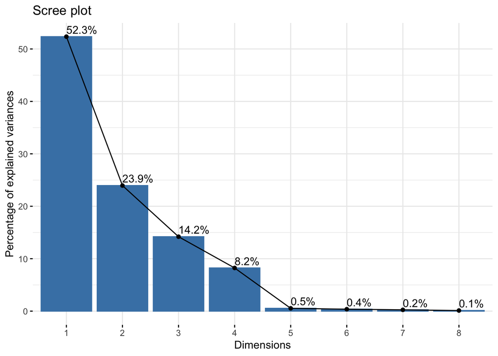

```r
plot_vp
```

Exemple d’une ACP réalisée :

```r
pca_list[5]
```

```
## $`pca_2011-2040_ssp585`
```

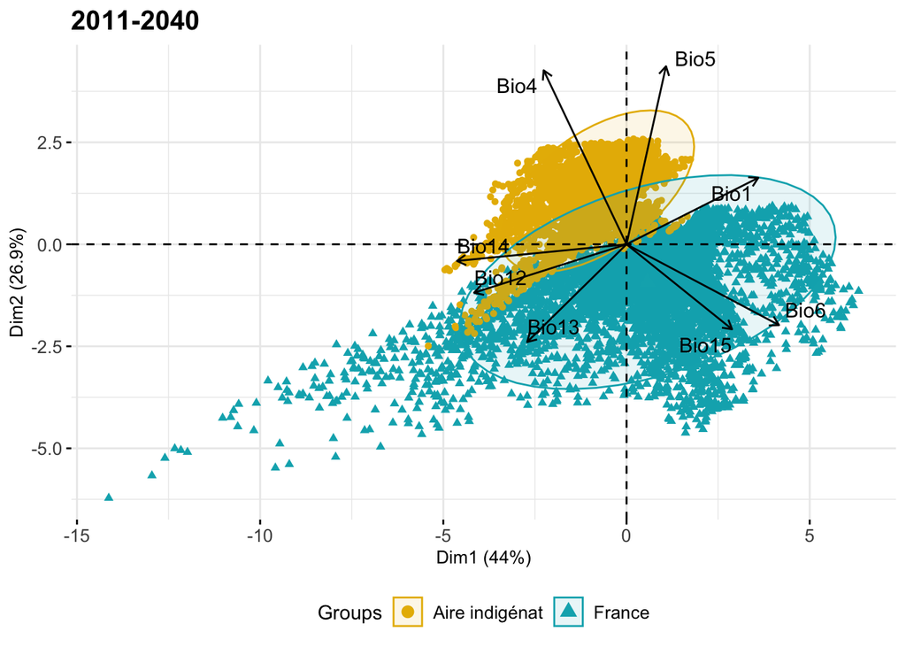

### 6.2. Sélectionner les points de concordance environnementale

Une fois l’ACP réalisée, les conditions environnementales au sein de l’aire d’indigénat de l’espèce et dans le pays d’introduction y sont projetées, donnant deux nuages de points. Les points concordants, c’est-à-dire les points du nuage de point correspondant aux conditions environnementales dans le pays d’introduction, ici la France, qui sont proches (à une distance max de 0.2 unité de l’axe de l’ACP) de ceux du nuage de point correspond aux conditions dans l’aire d’indigénat, sont sélectionnés (ellipse noir sur la figure 1b), puis enregistrés dans un data frame à part.

La boucle est telle que: If variables bioclimatiques null? - T -> Only on soil variables - F -> If period avec scenario? - T -> Period avec scénario: If aucun point proche sélectionné? - T -> Créer un data frame vide / plot sans point similaire - F -> Créer data frame avec points proche / créer plot avec points similaires - F -> Period sans scénario: If aucun point proche sélectionné? - T -> Créer un data frame vide / plot sans point similaire - F -> Créer data frame avec points proche /créer plot avec points similaires

```r
### 6.2. Select close points ####
print("Select Country points close to NR ones")
```

```
## [1] "Select Country points close to NR ones"
```

```r
## Plots with select points in Envir. space
dist_list <- list()
## Data Frame with select points
map_list <- list()
### 6.2.1. For Soil variables ####
if (is.null(varbio)) {
  ## Merge / make the combine species and country data
  merg <-rbind(
    rdf_count[rdf_count$Source == count_name, ],
    rdf_spe)
  ## sample data, add point in er that would fall outside of the perimeter
  ind <- ind_list[[1]]
  er <- ind$coord[substr(rownames(ind$coord), 1,
                         nchar(paste0( (substr(count_name, start = 1, stop = 2)),
                                       sep="_"))) == paste0( (substr(count_name, start = 1, stop = 2)), sep="_"), ]
  setDT(er, keep.rownames = "rowname")[]
  er <- as.data.frame(er)

  ## nr and threshold distance
  nr <- ind$coord[substr(rownames(ind$coord), 1, 3) == 'nr_', ]
  setDT(nr, keep.rownames = "rowname")[]
  nr <- as.data.frame(nr)

  ### Extract NR species and in country overlapping points
    ### Without Gradient by distance
    dist <- distance_semi_join(er, nr,
                               by = c("Dim.1","Dim.2"),
                               max_dist=md,
                               distance_col = "dist")
    ## If overlap = 0
    if (nrow(dist) == 0) {
      dist[nrow(dist) + 1,] = c("no_value",NA, NA)

      ## View plot
      chemElement <- "in_dist_sol"
      in_dist <- ggplot() +
        geom_point(data = er, aes(x = Dim.1, y = Dim.2, color = count_name))+
        geom_point(data = nr, aes(x = Dim.1, y = Dim.2, color = "Aire indigénat"))+

        #geom_point(data = dist, aes(x = Dim.1, y = Dim.2), shape = 1, size = 5 )+
        coord_fixed() +
        scale_colour_manual(values = c("Aire indigénat" = "#E7B800",
                                      "France" = "#00AFBB")) +
        theme(legend.position = "bottom") +
        ggtitle("(c)") +
        theme(plot.title = element_text(size = 25),
              axis.text=element_text(size=17),
              axis.title=element_text(size=17),
              legend.text = element_text(size=20),
              panel.grid.major = element_blank(), panel.grid.minor = element_blank(),
              panel.background = element_blank(),  axis.line = element_line(colour = "black")) +
        labs(fill = "", color ="")
      in_dist
      #assign(paste("ind_pca", j, sep = "_"), in_dist)
      dist_list[[chemElement]]  <- in_dist
      ### Points in the Country to study
      ## Merge data.frame
      map <- merge(dist, merg, by.x='rowname', by.y='cell') %>% insertRows(., 1, new = NA)
    } else {
      ## View plot
      chemElement <- "in_dist_sol"
      in_dist <- ggplot() +
        geom_point(data = er, aes(x = Dim.1, y = Dim.2, color = count_name))+
        geom_point(data = nr, aes(x = Dim.1, y = Dim.2, color = "Aire indigénat"))+

        geom_point(data = dist, aes(x = Dim.1, y = Dim.2, fill = "Similaire"),
                   shape = 1, size = 5 )+
        coord_fixed() +
        scale_colour_manual(values = c("Aire indigénat" = "#E7B800",
                                       "France" = "#00AFBB")) +
        ggtitle("(c)") +
        theme(legend.position = "bottom") +
        theme(plot.title = element_text(size = 25),
              axis.text=element_text(size=17),
              axis.title=element_text(size=17),
              legend.text = element_text(size=20),
              panel.grid.major = element_blank(), panel.grid.minor = element_blank(),
              panel.background = element_blank(),  axis.line = element_line(colour = "black")) +
        labs(fill = "", color ="")
      in_dist
      #assign(paste("ind_pca", j, sep = "_"), in_dist)
      dist_list[[chemElement]]  <- in_dist
      ### Points in the Country to study
      ## Merge data.frame
      map <- merge(dist, merg, by.x='rowname', by.y='cell') }
    ## Adding a new column with period and scenarios
    map$Sol <- "Niche édaphique potentielle"

    ## Add map in list (or rename map)
    chemElement <- "map_sol"
    map_list[[chemElement]]  <- map
    rm(map) } else {
### 6.2.2.For Bioclimatic variables ####
for (j in periods) {
  ## If there are SSP folders (future periods) ?
  if (length(list.files(path = paste(dir_cras,"CHELSA",j, sep="/"),
                        pattern = "*ssp", full.names = F) ) > 0) {
    ### 6.2.1. Periods with Scenarios ####
    print(paste0("Period ", j, " ..."))
    for (k in ssp) {
      print(paste0("Scenario ", k, " ..."))
      ## Merge / make the combine species and country data
      merg <-rbind(
        rdf_count[rdf_count$Source == (paste0(count_name, "_", j, k)), ],
        rdf_spe)
      ## sample data, add point in er that would fall outside of the perimeter
      ind <- ind_list[[grep(paste(j, k, sep="_"), names(ind_list), value = TRUE)]]
      # sample data, add point in er (etablishment range) that would fall outside of the perimeter
      er <- ind$coord[substr(rownames(ind$coord), 1,
                             nchar(paste0( (substr(count_name, start = 1, stop = 2)), j, k,
                                           sep="_"))) == paste0( (substr(count_name, start = 1, stop = 2)), j, k, sep="_"), ]
      setDT(er, keep.rownames = "rowname")[]
      er <- as.data.frame(er)

      ## nr (native range) and threshold distance
      nr <- ind$coord[substr(rownames(ind$coord), 1, 3) == 'nr_', ]
      setDT(nr, keep.rownames = "rowname")[]
      nr <- as.data.frame(nr)

      ### Extract NR species and in country overlapping points
        dist <- distance_semi_join(er, nr,
                                   by = c("Dim.1","Dim.2"),
                                   max_dist= md,
                                   distance_col = "dist")
        ### If overlap = 0
        if (nrow(dist) == 0) {
          dist[nrow(dist) + 1,] = c("no_value", NA, NA)

          ## View plot
          chemElement <- paste("in_dist", j, k, sep = "_")
          in_dist <- ggplot() +
            geom_point(data = er, aes(x = Dim.1, y = Dim.2, color = count_name))+
            geom_point(data = nr, aes(x = Dim.1, y = Dim.2, color = "Aire indigénat"))+
```

```r
            #geom_point(data = dist, aes(x = Dim.1, y = Dim.2), shape = 1, size = 5 )+
            coord_fixed() +
            scale_colour_manual(values = c("Aire indigénat" = "#E7B800",
                                           "France" = "#00AFBB")) +
            theme(legend.position = "bottom") +
            ggtitle(j) +
            theme(plot.title = element_text(size = 25, face = "bold"),
                  axis.text=element_text(size=17),
                  axis.title=element_text(size=17),
                  legend.text = element_text(size=20),
                  panel.grid.major = element_blank(), panel.grid.minor = element_blank(),
                  panel.background = element_blank(),  axis.line = element_line(colour = "black")) +
            labs(fill = "", color ="")
          in_dist
          #assign(paste("ind_pca", j, k, sep = "_"), in_dist)
          dist_list[[chemElement]]  <- in_dist

          ### Points in the Country to study
          ## Merge data.frame
          map <- merge(dist, merg, by.x='rowname', by.y='cell') %>% insertRows(., 1, new = NA)
        } else {
          ### If overlap =/= 0
          ## View plot
          chemElement <- paste("in_dist", j, k, sep = "_")
          in_dist <- ggplot() +
            geom_point(data = er, aes(x = Dim.1, y = Dim.2, color = count_name))+
            geom_point(data = nr, aes(x = Dim.1, y = Dim.2, color = "Aire indigénat"))+

            geom_point(data = dist, aes(x = Dim.1, y = Dim.2, fill = "Similaire"),
                       shape = 1, size = 5 )+
            coord_fixed() +
            scale_colour_manual(values = c("Aire indigénat" = "#E7B800",
                                           "France" = "#00AFBB")) +
            theme(legend.position = "bottom") +
            ggtitle(j) +
            theme(plot.title = element_text(size = 25, face = "bold"),
                  axis.text=element_text(size=17),
                  axis.title=element_text(size=17),
                  legend.text = element_text(size=20),
                  panel.grid.major = element_blank(), panel.grid.minor = element_blank(),
                  panel.background = element_blank(),  axis.line = element_line(colour = "black")) +
            labs(fill = "", color ="")
          in_dist
          #assign(paste("ind_pca", j, k, sep = "_"), in_dist)
          dist_list[[chemElement]]  <- in_dist

          ### Points in the Country to study
          ## Merge data.frame
          map <- merge(dist, merg, by.x='rowname', by.y='cell')
        }
        ## Adding a new column with period and scenarios
        map$Period <- j
        map$Scenario <- k

        ## Add map in list (or rename map)
        chemElement <- paste("map", j, k, sep = "_")
        map_list[[chemElement]]  <- map
        #assign(  paste("map", j, k, sep = "_"), map )
        rm(map)
    }
  } else {
    ## 6.2.2. Periods without Scenarios ####
    print(paste0("Period ", j, " ..."))
    ## Merge / make the combine species and country data
    merg <-rbind(
      rdf_count[rdf_count$Source == (paste(count_name, j, sep="_")), ],
      rdf_spe)
    ## sample data, add point in er that would fall outside of the perimeter
    ind <- ind_list[[grep(j, names(ind_list), value = TRUE)]]
    er <- ind$coord[substr(rownames(ind$coord), 1,
                           nchar(paste0( (substr(count_name, start = 1, stop = 2)), j,
                                         sep="_"))) == paste0( (substr(count_name, start = 1, stop = 2)), j, sep="_"), ]
    setDT(er, keep.rownames = "rowname")[]
    er <- as.data.frame(er)

    ## nr and threshold distance
    nr <- ind$coord[substr(rownames(ind$coord), 1, 3) == 'nr_', ]
    setDT(nr, keep.rownames = "rowname")[]
    nr <- as.data.frame(nr)

    ### Extract NR species and in country overlapping points
      dist <- distance_semi_join(er, nr,
                                 by = c("Dim.1","Dim.2"),
                                 max_dist=md,
                                 distance_col = "dist")
      ## If overlap = 0
      if (nrow(dist) == 0) {
        dist[nrow(dist) + 1,] = c("no_value",NA, NA)

        ## View plot
        chemElement <- paste("in_dist", j, sep = "_")
        in_dist <- ggplot() +
          geom_point(data = er, aes(x = Dim.1, y = Dim.2, color = count_name))+
          geom_point(data = nr, aes(x = Dim.1, y = Dim.2, color = "Aire indigénat"))+
          #geom_point(data = dist, aes(x = Dim.1, y = Dim.2), shape = 1, size = 5 )+
          coord_fixed() +
          scale_colour_manual(values = c("Aire indigénat" = "#E7B800",
                                         "France" = "#00AFBB")) +
          theme(legend.position = "bottom") +
          ggtitle(j) +
          theme(plot.title = element_text(size = 25, face = "bold"),
                axis.text=element_text(size=17),
                axis.title=element_text(size=17),
                legend.text = element_text(size=20),
                panel.grid.major = element_blank(), panel.grid.minor = element_blank(),
                panel.background = element_blank(),  axis.line = element_line(colour = "black")) +
          labs(fill = "", color ="")
        in_dist
        #assign(paste("ind_pca", j, sep = "_"), in_dist)
        dist_list[[chemElement]]  <- in_dist
        ### Points in the Country to study
        ## Merge data.frame
        map <- merge(dist, merg, by.x='rowname', by.y='cell') %>% insertRows(., 1, new = NA)
      } else {
        ## If overlap =/= 0
        ## View plot
        chemElement <- paste("in_dist", j, sep = "_")
        in_dist <- ggplot() +
          geom_point(data = er, aes(x = Dim.1, y = Dim.2, color = count_name))+
          geom_point(data = nr, aes(x = Dim.1, y = Dim.2, color = "Aire indigénat"))+
          geom_point(data = dist, aes(x = Dim.1, y = Dim.2, fill = "Similaire"),
                     shape = 1, size = 5 ) +
          coord_fixed() +
          scale_colour_manual(values = c("Aire indigénat" = "#E7B800",
                                         "France" = "#00AFBB")) +
          theme(legend.position = "bottom") +
          ggtitle(j) +
          theme(plot.title = element_text(size = 25, face = "bold"),
                axis.text=element_text(size=17),
                axis.title=element_text(size=17),
                legend.text = element_text(size=20),
                panel.grid.major = element_blank(), panel.grid.minor = element_blank(),
                panel.background = element_blank(),  axis.line = element_line(colour = "black")) +
          labs(fill = "", color ="")
        in_dist
        #assign(paste("ind_pca", j, sep = "_"), in_dist)
        dist_list[[chemElement]]  <- in_dist
        ### Points in the Country to study
        ## Merge data.frame
        map <- merge(dist, merg, by.x='rowname', by.y='cell') }
      ## Adding a new column with period and scenarios
      map$Period <- j
```

```r
      ## Add map in list (or rename map)
      chemElement <- paste("map", j, sep = "_")
      map_list[[chemElement]]  <- map
      #assign(  paste("map", j, sep = "_"), map )
      rm(map)
    }
  }
}
```

```
## [1] "Period 1951-1980 ..."
## [1] "Period 1981-2010 ..."
## [1] "Period 2011-2040 ..."
## [1] "Scenario ssp126 ..."
## [1] "Scenario ssp370 ..."
## [1] "Scenario ssp585 ..."
## [1] "Period 2041-2070 ..."
## [1] "Scenario ssp126 ..."
## [1] "Scenario ssp370 ..."
## [1] "Scenario ssp585 ..."
## [1] "Period 2071-2100 ..."
## [1] "Scenario ssp126 ..."
## [1] "Scenario ssp370 ..."
## [1] "Scenario ssp585 ..."
```

Exemple d’une ACP avec les points de concordance environnementale sélectionnés :

```r
dist_list[5]
```

```
## $`in_dist_2011-2040_ssp585`
```

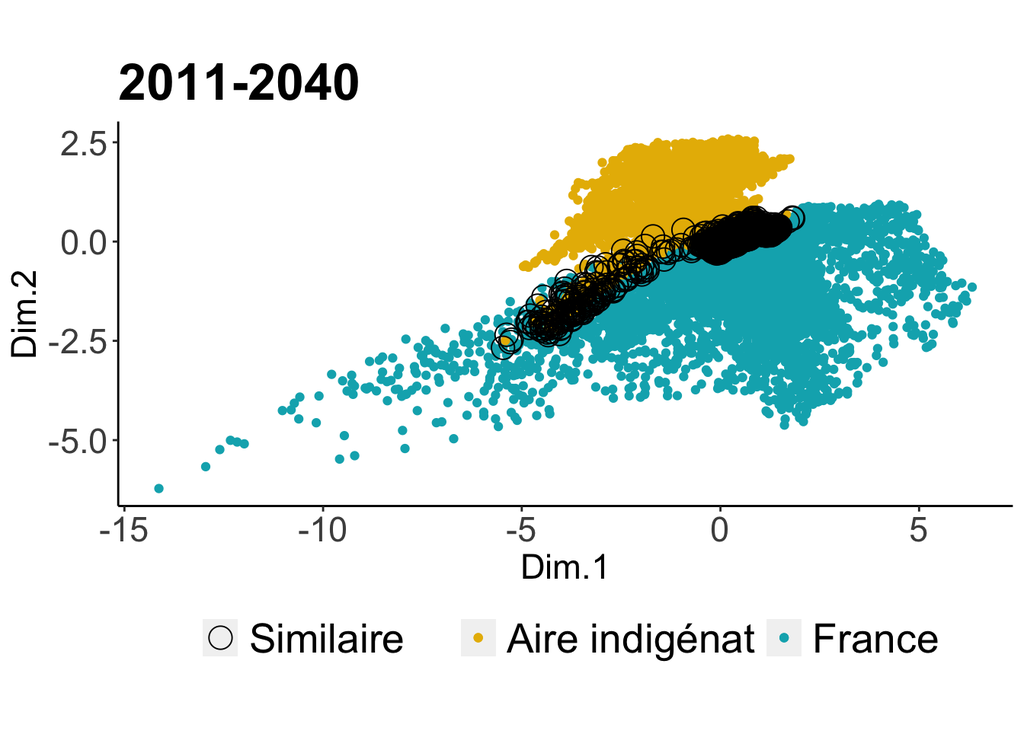

## 7. Projection sur les cartes dans le pays d’introduction

Étape 7: cartographier les points sur la carte du pays d’introduction à étudier.

Tout d’abord, fusionner la base de données des cartes.

```r
### Merge data maps
## Define there are not Scenario in "1951-1980" and "1981-2010" periods
if (!is.null(varbio)) {
map_list[[1]]["Scenario"]= NA
map_list[[2]]["Scenario"]= NA
}
map <- map_list %>%
  data.table::rbindlist(.)
```

Puis,

```r
#### 7. Mapping in Country ####
## by ABbreviation
AB <- map_data("world") %>% filter(region %in% count)
## Depending on the number of MD
  bplot_list <- list()
  if (is.null(varbio)) {
    chemElement <- "p_sol"
    p <- ggplot() +
      geom_polygon(data = AB, aes(x=long, y = lat, group = group), fill="#ECECEC") +
      geom_point( data=(map_list$map_sol),
                  aes(fill=Sol, x=x, y=y),
                  colour = "#632742", size = 1, na.rm = FALSE) +
      theme_void() + coord_map() + ggtitle("(b)") +
      theme(legend.position = "none")  +
      theme(plot.title = element_text(size = 25),
            legend.text = element_text(size=15)) +
      labs(fill ="")
    p
    bplot_list[[chemElement]] <- p
    rm(p)
  } else {
  ## Color of maps
  cols <- c("cyan2", "cyan4",
            "#A5D875", "#FFB74D", "#E23D00",
            "#6AAC57", "#FB8C00", "#B41500",
            "#41850B", "#EF6C00", "#7D0025")
  ncols <- character(0)
  for(j in periods) {
    if(is.na(map[grep(j, map$Period),]$Scenario[[1]])) {
      ncols <- c(ncols, j)
    } else {
      for (k in ssp) {
        ncols <- c(ncols, paste(j, k, sep="_", collapse = ","))
      }
    }
  }
  names(cols) <- ncols

  for (j in periods) {
    if(is.na(map[grep(j, map$Period),]$Scenario[[1]])) {
      # print("No scenario")
      chemElement <- paste("p", j, sep = "_")
      p <- ggplot() +
        geom_polygon(data = AB, aes(x=long, y = lat, group = group), fill="#ECECEC") +
        geom_point( data=(map[grep(j, map$Period),]),
                    aes(fill=Period, x=x, y=y),
                    colour = cols[j], size = 1, na.rm = FALSE) +
        theme_void() + coord_map() + ggtitle(j) +
        theme(legend.position = "none")  +
        theme(plot.title = element_text(size = 20, face = "bold"))

      bplot_list[[chemElement]] <- p
      #assign(paste("p", j, sep = "_"), p )
      rm(p)
    } else {
      # print("Scenario")
      for (k in ssp) {
        chemElement <- paste("p", j, k, sep = "_")
        p <- ggplot() +
          geom_polygon(data = AB, aes(x=long, y = lat, group = group), fill="#ECECEC") +
          geom_point( data=(map[grep(j, map$Period),] %>% .[grep(k, .$Scenario),]),
                      aes(fill=Period, x=x, y=y),
                      colour = cols[paste(j,k, sep="_")], size = 1, na.rm = FALSE) +
          theme_void() + coord_map() + ggtitle(paste(j,
                                                     #toupper(k),
                                                     sep=" ")) +
          theme(legend.position = "none")  +
          theme(plot.title = element_text(size = 20, face = "bold"))
        bplot_list[[chemElement]]  <- p
        #assign(paste("p", j, k, sep = "_"), p )
        rm(p)
        }
      }
    }
  }
```

Exemple des Cartes avec la distribution climatique potentielle de l’espèce dans le pays d’introduction sur la période “2071-2100” sous le scénario SSP5-8.5 :

```
## $`p_2071-2100_ssp585`
```

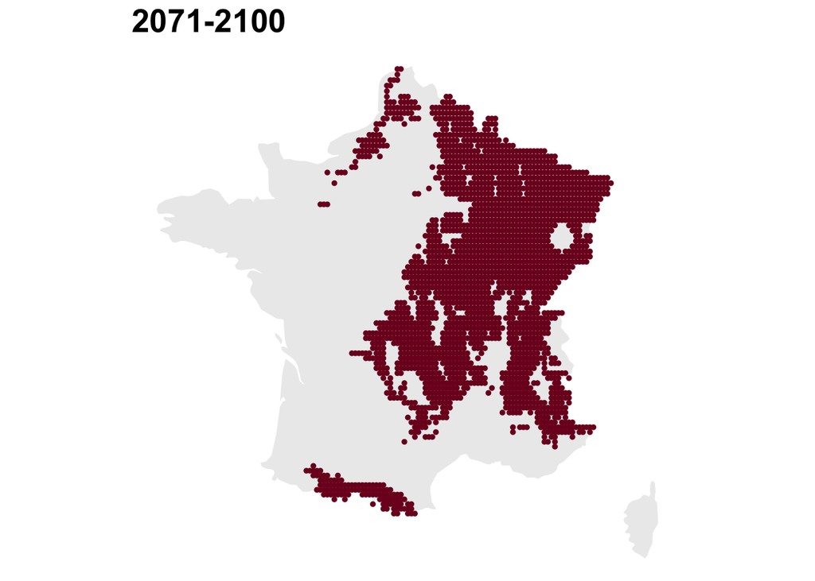

```r
if (is.null(varbio)) {bplot_list[1]} else {bplot_list[11]}
```

## 8. Points de distance entre les cartes

Étape 8, pour les variables bioclimatiques seulement : Sélectionnez le total (somme marginale) des points qui sont présentés sur chaque carte par Scénarios et par Périodes, puis présentés sur toutes les cartes quelles que soient les Périodes ou les Scénarios, c’est le total des totaux.

### 8.1. Total Scenarios

```r
## 8.1. Total Scenarios ####
if (!is.null(varbio)) {
map_dist_sc <- list()
for (j in periods) {
  if(!is.na(map[grep(j, map$Period),]$Scenario[[1]])) {
    for (k in ssp)  {
      ## If dfs in list are equal or not to NA (0 point)
      if (all(sapply(map_list[grep(k, names( map_list ), value = T )], \(x) anyNA(x$rowname)))) {
        ## If 0 point, so create df empty with NA inside
        dist <- data.frame(matrix(NA, nrow = 1, ncol = (ncol(map_list[[grep(k, names(map_list), value = TRUE)[1]]]))))
        colnames(dist) <- (colnames(map_list[[grep(k, names(map_list), value = TRUE)[1]]]))
        dist$Scenario <- k
        dist['ID'] <- NA
        dist['Presence'] <- NA
        chemElement <- paste("map_dist", k, sep = "_")
        map_dist_sc[[chemElement]]  <- dist
        rm(dist)
      } else {
        ## If no empty, see overlap between maps
        total <- rbind(map_list[[grep(k, names(map_list), value = TRUE)[1]]],
                       map_list[[grep(k, names(map_list), value = TRUE)[2]]],
                       map_list[[grep(k, names(map_list), value = TRUE)[3]]] )
        total['XY'] <- paste(total$x, total$y, sep="/")
        total <- total %>%
          add_count(XY, name = "Presence")
        total$Period <- NA
        total <- subset(total, select = -c(XY))
        total['ID'] <- sub("^[^_]*_", "", total$rowname)
        total <- total %>% drop_na(ID)
        ## Delete duplicated rows
        total = total[!duplicated(total$ID),]

        ## Add to the list
        chemElement <- paste("map_dist", k, sep = "_")
        map_dist_sc[[chemElement]]  <- total
        }
      }
    }
  }
}
```

### 8.2. Total Periods

```r
## 8.2. Total Periods ####
if (!is.null(varbio)) {
map_dist_pe <- list()
for (j in periods) {
  if(!is.na(map[grep(j, map$Period),]$Scenario[[1]])) {
  #   ## If dfs in list are equal or not to NA (0 point)
    if (all(sapply(map_list[grep(j, names(map_list), value = TRUE)], \(x) anyNA(x$rowname)))) {
      ## If 0 point, so create df empty with NA inside
      dist <- data.frame(matrix(NA, nrow = 1, ncol = (ncol(map_list[[grep(j, names(map_list), value = TRUE)[1]]]))))
      colnames(dist) <- (colnames(map_list[[grep(j, names(map_list), value = TRUE)[1]]]))
      dist$Period <- j
      dist['ID'] <- NA
      dist['Presence'] <- NA
      chemElement <- paste("map_dist", j, sep = "_")
      map_dist_pe[[chemElement]]  <- dist
      rm(dist)
    } else {
      ## If no empty, see overlap between maps
      total <- rbind(map_list[[grep(j, names(map_list), value = TRUE)[1]]],
                     map_list[[grep(j, names(map_list), value = TRUE)[2]]],
                     map_list[[grep(j, names(map_list), value = TRUE)[3]]] )
      total['XY'] <- paste(total$x, total$y, sep="/")
      total <- total %>%
        add_count(XY, name = "Presence")
      total$Scenario <- NA
      total <- subset(total, select = -c(XY))
      total['ID'] <- sub("^[^_]*_", "", total$rowname)
      total <- total %>% drop_na(ID)
      ## Delete duplicated rows
      total = total[!duplicated(total$ID),]

      ## Add to the list
      chemElement <- paste("map_dist", j, sep = "_")
      map_dist_pe[[chemElement]]  <- total
     }
    }
  }
}
```

### 8.3. Total

```r
## 8.3. Total ####
if (!is.null(varbio)) {
#map_dist_tot <- list()
if (all(sapply(c(map_dist_sc,map_dist_pe), \(x) anyNA(x$rowname)))) {
  ## If 0 point, so create df empty with NA inside
  Total <- data.frame(matrix(NA, nrow = 1, ncol = (ncol(map_list[[grep(j, names(map_list), value = TRUE)[1]]]))))
  colnames(Total) <- (colnames(map_list[[grep(j, names(map_list), value = TRUE)[1]]]))
  #chemElement <- paste0("map_dist_tot")
  #map_dist_tot[[chemElement]]  <- dist
  #rm(dist)
} else {
  ## If nb points >0
  Total <- rbind(map_dist_sc[[1]], map_dist_sc[[2]], map_dist_sc[[3]])
  Total['ID'] <- sub("^[^_]*_", "", Total$rowname)
  #map_dist_pe[[1]]['ID'] <- sub("^[^_]*_", "", map_dist_pe[[1]]$rowname)
  #Total <- Total %>% group_by(ID) %>% add_count(Presence, name = "Sum")
  ag <- aggregate(x = Total$Presence, by = list(Total$ID), FUN = sum)
  Total <- merge(x=Total, y=ag, by.x="ID", by.y="Group.1", all = TRUE)
  rm(ag)
  colnames(Total)[colnames(Total) == "x.y"] ="Sum"
  colnames(Total)[colnames(Total) == "x.x"] ="x"
  #Total$Sum <- ave(Total$ID,FUN=sum)
  }
}
```

## 9. Cartographie des points totaux

Étape 9: cartographie des totaux obtenus en partie 8.

### 9.1. Carte Total Scenarios

```r
### 9.1. Map Total Scenarios ####
if (!is.null(varbio)) {
plot_dist_sc <- list()
for (k in ssp) {
      ## If dfs in list are equal or not to NA (0 point)
      if (sapply(map_dist_sc[grep(k, names(map_dist_sc), value = TRUE)], \(x) anyNA(x$rowname))) {
        ## If 0 point, just mapping empty country
        chemElement <- paste("plot", k, sep = "_")
      d <- ggplot() +
        geom_polygon(data = AB, aes(x=long, y = lat, group = group), fill="#ECECEC") +
        # geom_point( data=map_dist_sc[[grep(k, names(map_dist_sc), value = TRUE)]],
        #             aes(fill=Period, x=x, y=y),
        #             colour = "#6AB1D6", size = 1) +
        theme_void() + coord_map() + ggtitle("2011-2100") +
        theme(legend.position = "none")  +
        theme(plot.title = element_text(size = 20, face = "bold"))
      plot_dist_sc[[chemElement]]  <- d
      #assign(paste("p", j, k, sep = "_"), p )
      rm(d)
      } else {
        ## If points,
        chemElement <- paste("plot", k, sep = "_")
        d <- ggplot() +
          geom_polygon(data = AB, aes(x=long, y = lat, group = group), fill="#ECECEC") +
          geom_point(data=map_dist_sc[[grep(k, names(map_dist_sc), value = TRUE)]],
                      aes(x=x, y=y,
                      colour = as.character(Presence)), size = 1) +
          theme_void() + coord_map() + ggtitle("Toutes périodes") +
          scale_color_manual(name = "Présence totale", values=c("#97CF8CFF", "#32A154FF", "#165D3CFF")) +
          theme(legend.position = "bottom")  +
          theme(plot.title = element_text(size = 20, face = "bold"))
        d
        plot_dist_sc[[chemElement]]  <- d
        #assign(paste("p", j, k, sep = "_"), p )
        rm(d)
    }
  }
}
```

Exemple de cartes avec le total des cartes pour scénarios SSP1-2.6 :

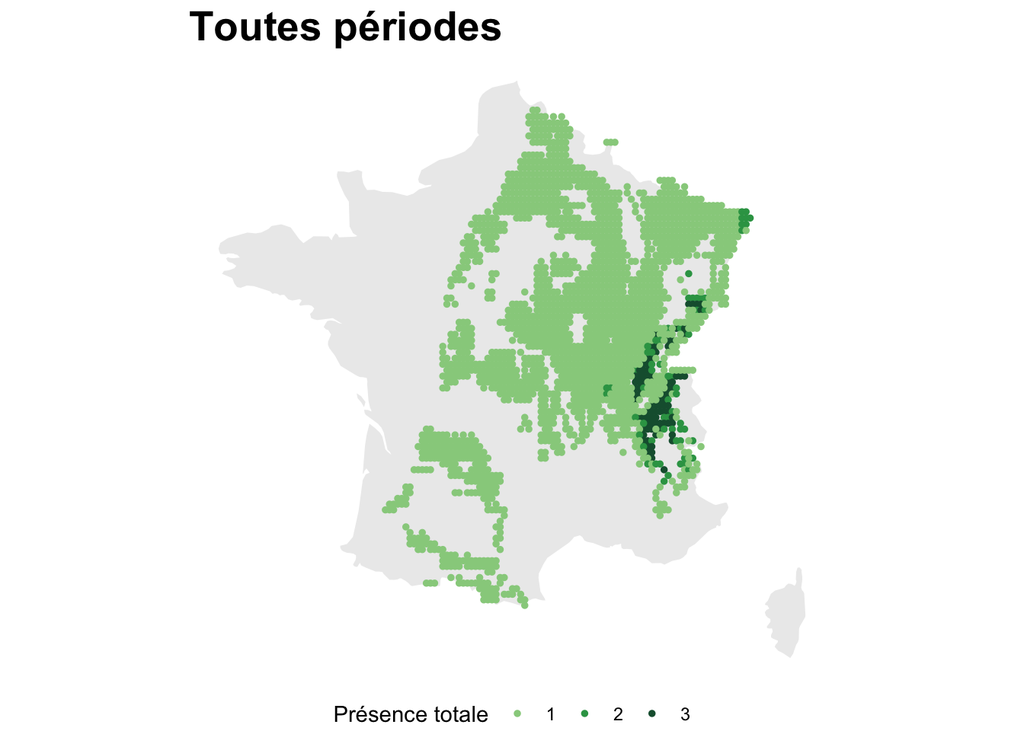

```r
plot_dist_sc[1]
```

### 9.2. Carte Total Periods

```r
### 9.2. Map Total Periods ####
if (!is.null(varbio)) {
plot_dist_pe <- list()
for (j in periods) {
  ## Only keep periods with scenarios
  if(!is.na(map[grep(j, map$Period),]$Scenario[[1]])) {
    ## If dfs in list are equal or not to NA (0 point)
    if (sapply(map_dist_pe[grep(j, names(map_dist_pe), value = TRUE)], \(x) anyNA(x$rowname))) {
      ## If 0 point, just mapping empty country
      chemElement <- paste("plot", j, sep = "_")
      d <- ggplot() +
        geom_polygon(data = AB, aes(x=long, y = lat, group = group), fill="#ECECEC") +
        # geom_point( data=map_dist_pe[[grep(j, names(map_dist_pe), value = TRUE)]],
        #             aes(fill=Period, x=x, y=y),
        #             colour = "#6AB1D6", size = 1) +
        theme_void() + coord_map() + ggtitle(j) +
        #theme(legend.position = "none")  +
        theme(plot.title = element_text(size = 20, face = "bold"))
      plot_dist_pe[[chemElement]]  <- d
      #assign(paste("p", j, k, sep = "_"), p )
      rm(d) } else {
        ## If points,
        chemElement <- paste("plot", j, sep = "_")
        d <- ggplot() +
          geom_polygon(data = AB, aes(x=long, y = lat, group = group), fill="#ECECEC") +
          geom_point( data=map_dist_pe[[grep(j, names(map_dist_pe), value = TRUE)]],
                      aes(x=x, y=y,
                      colour = as.character(Presence)), size = 1) +
          theme_void() + coord_map() + ggtitle(j) +
          scale_color_manual(name = "Présence totale", values=c("#97CF8CFF", "#32A154FF", "#165D3CFF")) +
          theme(legend.position = "bottom")  +
          theme(plot.title = element_text(size = 20, face = "bold"))
        d
        plot_dist_pe[[chemElement]]  <- d
        #assign(paste("p", j, k, sep = "_"), p )
        rm(d)
      }
    }
  }
}
```

Exemple de cartes avec le total des cartes pour périodes “2011-2040” :

```
## $`plot_2011-2040`
```

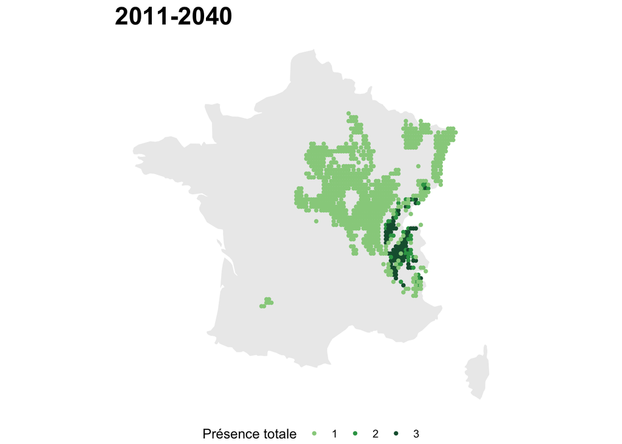

```r
plot_dist_pe[1]
```

### 9.3. Carte total

Puis finalement la carte avec le total. Une valeur de 9 sur la carte indique que la localité géographique sera bioclimatiquement favorable sur l’ensemble de la période de 2010 à 2100, sur l’ensemble des scénarios considérés. Une valeur de 1 indique, à l’inverse, que localité géographique sera bioclimatiquement favorable sur seulement uen seule période pour un seul scénario considéré.

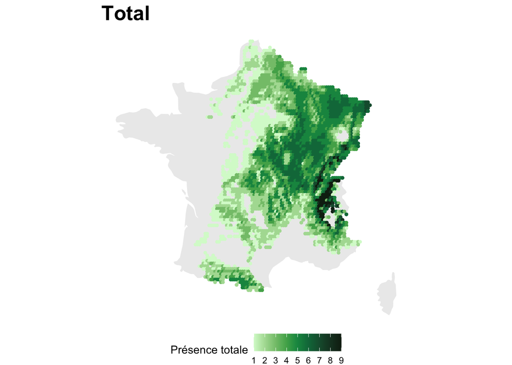

```r
### 9.3. Map Total ####
if (!is.null(varbio)) {
## If total in list are equal or not to NA (0 point)
if (any(is.na(Total$rowname))) {
  ptot <- ggplot() +
    geom_polygon(data = AB, aes(x=long, y = lat, group = group), fill="#ECECEC") +
    # geom_point( data=Total,
    #             aes(fill=Period, x=x, y=y),
    #             colour = "#317197", size = 1) +
    theme_void() + coord_map() + ggtitle("Total") +
    theme(legend.position = "none")  +
    theme(plot.title = element_text(size = 20, face = "bold"))
  } else {
    # If points >0,
    if(length(unique(Total$Sum)) > 3) {
  ptot <- ggplot() +
    geom_polygon(data = AB, aes(x=long, y = lat, group = group), fill="#ECECEC") +
    geom_point( data=Total,
                aes(x=x, y=y,
                colour = Sum), size = 1) +
    theme_void() + coord_map() + ggtitle("Total") +
    paletteer::scale_colour_paletteer_c("pals::ocean.algae", direction=-1,
                                        name = "Présence totale",
                                        breaks = c(1:9))  +
    theme(legend.position = "bottom")  +
    theme(plot.title = element_text(size = 20, face = "bold"))
  ptot
    } else {
      ptot <- ggplot() +
        geom_polygon(data = AB, aes(x=long, y = lat, group = group), fill="#ECECEC") +
        geom_point( data=Total,
                    aes(x=x, y=y,
                        colour = factor(Sum)), size = 1) +
        theme_void() + coord_map() + ggtitle("Total") +
        scale_color_manual(name = "Présence totale", values=c("#97CF8CFF", "#32A154FF", "#165D3CFF")) +
        theme(legend.position = "bottom")  +
        theme(plot.title = element_text(size = 20, face = "bold"))
      ptot
    }
  }
}
```

## 10. Disposition des cartes ensemble

Étape 10 : dernière étape, l’objectif est de rassembler l’ensemble des cartes (ou ACP) produitent sur une seule page, à l’aide de la fonction `plot_grid` du package `cowplot`.

### 10.1. Cartographie avec les variables édaphiques seulement

La première sous-étape est le regroupement des cartes et ACP produitent lorsque seulement les variables édaphiques sont étudiées :

```r
### 10.1. Only soil variables ####
if (is.null(varbio)) {
  print("Print all graphs with only soil variables")

  grid.arrange(pca_list[[1]], arrangeGrob(bplot_list[[1]], dist_list[[1]]), ncol = 2)

  library(cowplot)
  cowplot::plot_grid(pca_list[[1]], dist_list[[1]], bplot_list[[1]], labels=c("A", "B", "C"), ncol = 1, nrow = 3)

  patch_sol <- (wrap_elements(pca_list[[1]]) + wrap_elements(dist_list[[1]]) + wrap_elements(bplot_list[[1]]) ) +
    plot_annotation(
      title = paste("Niches édaphiques potentielles projetées de", i, "en", count_name, sep=" "),
      subtitle = paste0("(Avec les variables édaphiques ",
                               paste(sort(soil), collapse = ","),
                        " en profondeur ", paste(depth, collapse = ","),")"),
      theme = theme(plot.title = element_text(size = 30, face="bold", hjust = 0.5),
                    plot.subtitle = element_text(size = 20, hjust = 0.5)))
  patch_sol
  ggsave((paste0(paste("Sol", i, sep="_"), ".pdf")),width=17, height=9,
         patch_sol, path= dir_pc) #"Sol", sep="/"))
}
```

### 10.2. Cartographie avec les variables bioclimatiques

#### 10.2.1. Sous-titres

Lorsque les variables bioclimatiques sont étudiées, la deuxième sous-étape est de définir les sous-titles qui seront utilisés sur la page regroupant les cartes ensemble.

```r
### 10.2. With bioclimatic variables ####
    if (!is.null(varbio)) {
      ### 10.2.1. Subtitles ####
if (is.null(soil)) { sub = paste0("(Avec les variables bioclimatiques ",
                                  paste(sort(varbio), collapse = ","), ")") } else {
    sub = paste0("(Avec les variables bioclimatiques ", paste(sort(varbio), collapse = ","),
                 " et sols ", paste(soil, collapse = ","),
                 " en profondeur ", paste(depth, collapse = ","), "cm)")
  }
if (is.null(soil)) { sub = paste0("(Avec les variables bioclimatiques ",
                              paste(sort(varbio), collapse = ","), ")") } else {
if (is.null(varbio)) { sub = paste0("(Avec les sols ", paste(soil, collapse = ","),
                                  " de profondeur ", paste(depth, collapse = ","), "cm)") } else {
sub = paste0("(Avec les variables bioclimatiques ", paste(sort(varbio), collapse = ","),
             " et sols ", paste(soil, collapse = ","),
             " de profondeur ", paste(depth, collapse = ","), "cm)")  } } }
```

#### 10.2.2. Cartographie de l’aire d’indigénat de l’espèce

L’objectif ensuite est de cartographier l’aire d’indigénat de l’espèce afin d’être informé de sa localisation géographique dans le monde.

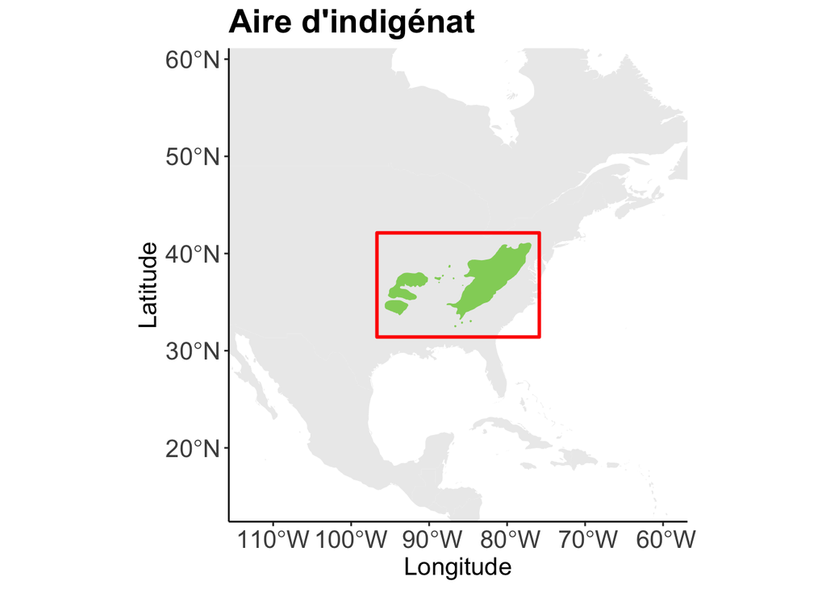

```r
    ### 10.2.2. Native Range map ####
    ## First, add Native Range in Reference maps
    ## World map
    world_coordinates <- map_data("world") %>%
      st_as_sf(coords = c("long", "lat"), dim = "XY") %>%
      st_set_crs(4326)
    ## Find min and max range coordinates
    coord_range <- st_as_sf(range)
    coord_range <- sf::st_cast(coord_range, "MULTIPOLYGON")
    coord_range <- data.frame(st_coordinates(coord_range$geometry))
    ## Do border of Native range
    bb <-
      c(
        "xmin" = min(coord_range$X)-1,
        "xmax" = max(coord_range$X)+1,
        "ymin" = min(coord_range$Y)-1,
        "ymax" = max(coord_range$Y)+1
      ) %>%
      sf::st_bbox() %>%
      sf::st_as_sfc() %>%
      sf::st_as_sf(crs = 4326) %>%
      sf::st_transform(crs = 4326)

    ## Plot 1: Native Range in World
    world <-  ggplot() +
      geom_map(
      data = map_data("world"), map = map_data("world"), fill = "#ECECEC",
      aes(long, lat, map_id = region) ) +
      #theme_void() +
      #coord_map("ortho", orientation = c(90, 0, 0)) +
      geom_sf(data = bb, colour = "red", fill = NA, linewidth = 1) +
      tidyterra::geom_spatvector(data = range, fill = "#92D168FF", linewidth = NA) +
      coord_sf(xlim = c((min(coord_range$X)-20), (max(coord_range$X)+20)),
               ylim = c((min(coord_range$Y)-20), (max(coord_range$Y)+20)), expand = FALSE) +
      theme(plot.title = element_text(size = 20, face="bold"),
            axis.text = element_text(size = 15),
            axis.title = element_text(size = 15),
            #legend.title = element_blank(),
            panel.grid.major = element_blank(), panel.grid.minor = element_blank(),
            panel.background = element_blank(),  axis.line = element_line(colour = "black")) +
      labs(y = "Latitude",
           x = "Longitude") + ggtitle("Aire d'indigénat")
    world
```

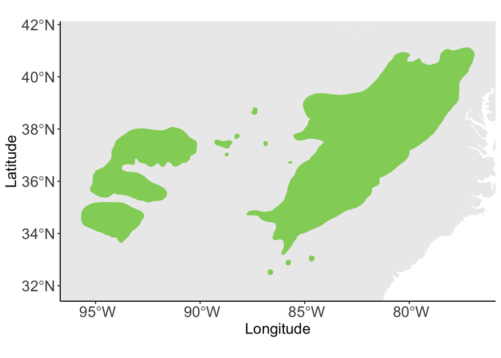

```r
    #crds(range)

    ## Plot 2: only focus on Native Range
    prange <- ggplot() +
      geom_map(
        data = map_data("world"), map = map_data("world"), fill = "#ECECEC",
        aes(long, lat, map_id = region) ) +
      tidyterra::geom_spatvector(data = range, fill = "#92D168FF", linewidth = NA) +
      theme(plot.title = element_text(size = 20, face = "bold")) +
      coord_sf(xlim = c((min(coord_range$X)-1), (max(coord_range$X)+1)),
               ylim = c((min(coord_range$Y)-1), (max(coord_range$Y)+1)), expand = FALSE) +
      theme(text = element_text(size = 15),
            legend.title = element_blank(),
            axis.text = element_text(size = 15),
            axis.title = element_text(size = 15),
            panel.grid.major = element_blank(), panel.grid.minor = element_blank(),
            panel.background = element_blank(),  axis.line = element_line(colour = "black")) +
      labs(y = "Latitude",
           x = "Longitude")
    prange
```

### 10.2.3. Arrangement 1 : Cartes de distribution potentielle

Pour finir, l’objectif est de regrouper l’ensemble des cartes de la distribution potentielle de l’espèce au sein du pays d’introduction sur une seule page :

```r
### 10.2.3. Arrange 1: Maps of potential distribution of species ####
## Arrange
p1 <- cowplot::plot_grid(world, prange, bplot_list[[1]], bplot_list[[2]], ncol = 4) +
  plot_annotation( title = paste0("Référence"),
                   theme = theme(plot.title = element_text(size = 25, face="bold")))
p2 <- cowplot::plot_grid(bplot_list[[3]], bplot_list[[6]], bplot_list[[9]], plot_dist_sc[[1]], ncol = 4) +
  plot_annotation( title = paste0("Scénario SSP1-2.6"),
                   theme = theme(plot.title = element_text(size = 25, face="bold")))
p3 <- cowplot::plot_grid(bplot_list[[4]], bplot_list[[7]], bplot_list[[10]], plot_dist_sc[[2]], ncol = 4) +
  plot_annotation( title = paste0("Scénario SSP3-7.0"),
                   theme = theme(plot.title = element_text(size = 25, face="bold")))
p4 <- cowplot::plot_grid(bplot_list[[5]], bplot_list[[8]], bplot_list[[11]], plot_dist_sc[[3]], ncol = 4) +
  plot_annotation( title = paste0("Scénario SSP5-8.5"),
                   theme = theme(plot.title = element_text(size = 25, face="bold")))
p5 <- cowplot::plot_grid(plot_dist_pe[[1]], plot_dist_pe[[2]], plot_dist_pe[[3]], ptot, ncol = 4) +
  plot_annotation( title = paste0("Tous Scénarios"),
                   theme = theme(plot.title = element_text(size = 25, face="bold")))

patch1 <- (wrap_elements(p1) / wrap_elements(p2) / wrap_elements(p3) / wrap_elements(p4) / wrap_elements(p5)) +
  plot_annotation(
    title = paste("Niche Bioclimatique Potentielle Projetée de", i, "en", count_name, sep=" "),
    subtitle = sub,
    theme = theme(plot.title = element_text(size = 30, face="bold", hjust = 0.5),
                  plot.subtitle = element_text(size = 20, hjust = 0.5)))
#patch1
```

### 10.2.4. Arrangement 2: ACP

De même, les ACP pour sur chaque période et scénario sont regroupés :

```r
### 10.2.4. Arrange 2: Arrange PCA plots ####
p6 <- (pca_list[[1]] + pca_list[[2]]) +
  plot_annotation( title = paste0("Référence"),
                   theme = theme(plot.title = element_text(size = 15, face="bold")))
p7 <- (pca_list[[3]]+ pca_list[[6]] + pca_list[[9]]) +
  plot_annotation( title = paste0("Scénario SSP1-2.6"),
                   theme = theme(plot.title = element_text(size = 15, face="bold")))
p8 <- (pca_list[[4]]+ pca_list[[7]] + pca_list[[10]]) +
  plot_annotation( title = paste0("Scénario SSP3-7.0"),
                   theme = theme(plot.title = element_text(size = 15, face="bold")))
p9 <- (pca_list[[5]]+ pca_list[[8]] + pca_list[[11]]) +
  plot_annotation( title = paste0("Scénario SSP5-8.5"),
                   theme = theme(plot.title = element_text(size = 15, face="bold")))

patch2 <- (wrap_elements(p6)/wrap_elements(p7)/wrap_elements(p8)/wrap_elements(p9)) +
  plot_annotation(
    title = paste("ACP de", i, "en", count_name, sep=" "),
    subtitle = sub,
    theme = theme(plot.title = element_text(size = 20, face="bold", hjust = 0.5),
                  plot.subtitle = element_text(size = 15, hjust = 0.5)))
#patch2
```

### 10.2.5. Arrangement 3 : ACP avec points concordants

```r
### 10.2.5. Arrange 3: Arrange Close points plots ####
p10 <- (dist_list[[1]] + dist_list[[2]]) +
  plot_annotation( title = paste0("Référence"),
                   theme = theme(plot.title = element_text(size = 30, face="bold")))
p11 <- (dist_list[[3]]+ dist_list[[6]] + dist_list[[9]]) +
  plot_annotation( title = paste0("Scénario SSP1-2.6"),
                   theme = theme(plot.title = element_text(size = 30, face="bold")))
p12 <- (dist_list[[4]]+ dist_list[[7]] + dist_list[[10]]) +
  plot_annotation( title = paste0("Scénario SSP3-7.0"),
                   theme = theme(plot.title = element_text(size = 30, face="bold")))
p13 <- (dist_list[[5]]+ dist_list[[8]] + dist_list[[11]]) +
  plot_annotation( title = paste0("Scénario SSP5-8.5"),
                   theme = theme(plot.title = element_text(size = 30, face="bold")))

patch3 <- (wrap_elements(p10)/wrap_elements(p11)/wrap_elements(p12)/wrap_elements(p13)) +
  plot_annotation(
    title = paste("Espace environnemental de", i, "en", count_name, sep=" "),
    subtitle = sub,
    theme = theme(plot.title = element_text(size = 35, face="bold", hjust = 0.5),
                  plot.subtitle = element_text(size = 20, hjust = 0.5)))
#patch3
```